# Projeto Integrador - Modelagem

Andre Giusti Dambry, Flavio Barbosa Shirahige, Michel Maurice Conjaud Neto e Tiago Evangelista Pardo

2023-09-13

## Etapa de Modelagem - Introdução

O objetivo dessa parte do Projeto Integrador é desenvolver um modelo previtivo para indicar se uma empresa irá falir em até dois anos a partir da avaliação de quatro classes de modelos: regressão logística, RIDGE/LASSO, floresta aleatória e Boosting. O pipeline de pré-processamento dos dados foi feito em Python. Nessa etapa de pré-processamento, foi criada a variável chamada will_close, que é a variável resposta desse processo de modelagem. Nela, o valor “1” significa que a empresa fechará em até 2 anos e ZERO (0) que a empresa não fechou nesse mesmo período de dois anos após 2012 (ano de referência para a modelagem).

Além dos modelos listados acima, serão utilizadas outras abordagens, como implementar o método de seleção de subconjuntos para as variáveis preditoras (stepwise) e testar o desempenho para modelagem por porte da empresa (pequena, média e grande), a ser feito de forma separada.

Para avaliar o desempenho de cada um dos modelos de classificação estimados, será utilizado a área sob a curva ROC (AUC), que mede a probabilidade de uma observação de evento ocorrer (no caso, se a empresa irá fechar) ter uma probabilidade maior do que uma observação do grupo de referência. Isto é, qual é o percentual de classificação correta do modelo em questão. Logo, um valor de AUC de um dado modelo igual 1 indica um desempenho de 100% na classificação e um valor de 0,5 significa que o modelo não é capaz de classificar de forma melhor do que uma escolha num processo aleatório.

O primeiro passo é importar os dados. Serão removidos os ID das empresas (comp_id), pois essas informações não serão utilizados na modelagem:

```r
dados <- read_csv("C:/Users/Flavio/Dropbox/My PC (LAPTOP-FVTATBSD)/Documents/Pós Insper Data Science/Projeto Integrador AEM I e CCD/df.csv", show_col_types = FALSE) %>%
  dplyr::select(-comp_id)
```

A próxima etapa é verificar se os dados foram migrados corretamente.

```r
skim(dados)
```

Data summary

| Name | dados |
| --- | --- |
| Number of rows | 21045 |
| Number of columns | 25 |
| _______________________ |  |
| Column type frequency: |  |
| character | 2 |
| numeric | 23 |
| ________________________ |  |
| Group variables | None |

**Variable type: character**

| skim_variable | n_missing | complete_rate | min | max | empty | n_unique | whitespace |
| --- | --- | --- | --- | --- | --- | --- | --- |
| region_m | 0 | 1 | 4 | 7 | 0 | 3 | 0 |
| comp_size | 0 | 1 | 5 | 7 | 0 | 3 | 0 |

**Variable type: numeric**

| skim_variable | n_missing | complete_rate | mean | sd | p0 | p25 | p50 | p75 | p100 | hist |
| --- | --- | --- | --- | --- | --- | --- | --- | --- | --- | --- |
| amort | 0 | 1 | 16451.89 | 176911.03 | -14896.30 | 0.00 | 488.89 | 2937.04 | 15921181.00 | ▇▁▁▁▁ |
| curr_assets | 0 | 1 | 195797.70 | 1850563.21 | -34600.00 | 1851.85 | 7970.37 | 31181.48 | 91489976.00 | ▇▁▁▁▁ |
| curr_liab | 0 | 1 | 175180.31 | 2812845.05 | -8759.26 | 1944.44 | 10829.63 | 40118.52 | 326405120.00 | ▇▁▁▁▁ |
| extra_exp | 0 | 1 | 1956.30 | 122313.58 | -1418.52 | 0.00 | 0.00 | 0.00 | 17041718.00 | ▇▁▁▁▁ |
| extra_inc | 0 | 1 | 2888.42 | 124608.73 | -7.41 | 0.00 | 0.00 | 0.00 | 17092322.00 | ▇▁▁▁▁ |
| extra_profit_loss | 0 | 1 | 931.96 | 41562.69 | -2211577.75 | 0.00 | 0.00 | 0.00 | 3253703.75 | ▁▁▇▁▁ |
| fixed_assets | 0 | 1 | 281762.29 | 6255207.51 | 0.00 | 0.00 | 2348.15 | 28433.33 | 686351872.00 | ▇▁▁▁▁ |
| inc_bef_tax | 0 | 1 | 19970.66 | 666956.74 | -13973230.00 | -4807.41 | -74.07 | 2485.19 | 77992592.00 | ▇▁▁▁▁ |
| intang_assets | 0 | 1 | 13727.75 | 1107405.46 | -29.63 | 0.00 | 0.00 | 0.00 | 159444448.00 | ▇▁▁▁▁ |
| inventories | 0 | 1 | 58179.07 | 666267.74 | -2607.41 | 0.00 | 240.74 | 4855.56 | 30963558.00 | ▇▁▁▁▁ |
| liq_assets | 0 | 1 | 37482.21 | 644036.58 | -130333.34 | 288.89 | 1562.96 | 6837.04 | 79224256.00 | ▇▁▁▁▁ |
| material_exp | 0 | 1 | 317587.66 | 2686433.75 | -273433.34 | 2392.59 | 18507.41 | 72274.07 | 96001928.00 | ▇▁▁▁▁ |
| personnel_exp | 0 | 1 | 84200.94 | 685157.63 | -147066.67 | 285.19 | 7218.52 | 22977.78 | 45855412.00 | ▇▁▁▁▁ |
| profit_loss_year | 0 | 1 | 5316.06 | 255193.46 | -13973230.00 | -4811.11 | -74.07 | 1574.07 | 17001730.00 | ▁▁▇▁▁ |
| sales_x | 0 | 1 | 249859.19 | 780327.20 | 1003.70 | 16566.67 | 46888.89 | 146500.00 | 9997007.00 | ▇▁▁▁▁ |
| share_eq | 0 | 1 | 214867.90 | 5351237.11 | -39509640.00 | -7433.33 | 1959.26 | 21240.74 | 692925952.00 | ▇▁▁▁▁ |
| subscribed_cap | 0 | 1 | 76731.98 | 1500646.10 | -303.70 | 1851.85 | 1851.85 | 11111.11 | 159444448.00 | ▇▁▁▁▁ |
| tang_assets | 0 | 1 | 208393.40 | 3561213.51 | 0.00 | 0.00 | 2000.00 | 25574.07 | 451100736.00 | ▇▁▁▁▁ |
| urban_m | 0 | 1 | 2.08 | 0.85 | 1.00 | 1.00 | 2.00 | 3.00 | 3.00 | ▆▁▆▁▇ |
| labor_avg | 0 | 1 | 0.90 | 3.85 | 0.08 | 0.12 | 0.33 | 0.90 | 151.33 | ▇▁▁▁▁ |
| will_close | 0 | 1 | 0.03 | 0.16 | 0.00 | 0.00 | 0.00 | 0.00 | 1.00 | ▇▁▁▁▁ |
| curr_idx_liq | 0 | 1 | 624.89 | 16569.16 | -1366.67 | 0.27 | 1.11 | 3.59 | 1851851.88 | ▇▁▁▁▁ |
| comp_age | 0 | 1 | 8.47 | 7.01 | -4.00 | 2.00 | 7.00 | 14.00 | 63.00 | ▇▆▁▁▁ |

Como há variáveis categóricas, vamos transformá-las em fator para a modelagem:

```r
dados <- dados %>%
  mutate_if(is.character, ~as.factor(.x))
```

## Análise dos Modelos

Nesse passo, vamos construir os modelos para predizer a variável resposta will_close (se a empresa irá falir em até dois anos), a saber:

- Regressão Logísitica
- Rigde
- LASSO
- Floresta Aleatória
- Boosting

A etapa seguinte é criar os datasets de treinamento e teste, onde 80% do dataset será de treinamento:

```r
set.seed(321)

idx <- sample(nrow(dados), size = .80 * nrow(dados), replace = FALSE)

treino <- dados[idx,]
teste  <- dados[-idx,]
```

### Regressão Logística

O primeiro modelo a ser estimado é o de regressão logística:

```r
log <- glm(will_close ~ ., data = treino, family = 'binomial')
```

```
## Warning: glm.fit: probabilidades ajustadas numericamente 0 ou 1 ocorreu
```

```r
summary(log)
```

```
##
## Call:
## glm(formula = will_close ~ ., family = "binomial", data = treino)
##
## Coefficients:
##                     Estimate Std. Error z value Pr(>|z|)
## (Intercept)       -4.547e+00  1.978e-01 -22.996   <2e-16 ***
## amort              2.425e-07  1.122e-06   0.216   0.8288
## curr_assets       -1.026e-07  2.301e-07  -0.446   0.6555
## curr_liab          9.653e-09  1.298e-07   0.074   0.9407
## extra_exp         -2.868e-04  2.736e-04  -1.048   0.2944
## extra_inc          2.781e-04  2.733e-04   1.018   0.3088
## extra_profit_loss -2.764e-04  2.733e-04  -1.011   0.3118
## fixed_assets      -8.572e-08  2.041e-07  -0.420   0.6745
## inc_bef_tax        4.159e-08  3.239e-07   0.128   0.8978
## intang_assets     -8.620e-08  6.383e-07  -0.135   0.8926
## inventories        8.596e-08  2.678e-07   0.321   0.7482
## liq_assets         1.347e-07  2.160e-07   0.623   0.5330
## material_exp       1.926e-08  4.944e-08   0.390   0.6968
## personnel_exp     -1.952e-07  4.210e-07  -0.464   0.6428
## profit_loss_year   1.289e-07  5.440e-07   0.237   0.8127
## sales_x           -1.623e-08  1.024e-07  -0.159   0.8740
## share_eq           4.559e-08  1.135e-07   0.402   0.6880
## subscribed_cap    -6.956e-09  1.133e-07  -0.061   0.9510
## tang_assets        5.322e-08  2.016e-07   0.264   0.7918
## urban_m            7.012e-02  6.309e-02   1.111   0.2664
## region_mEast      -2.565e-01  1.301e-01  -1.971   0.0487 *
## region_mWest      -1.201e-01  1.486e-01  -0.808   0.4191
## labor_avg          2.826e-03  5.150e-02   0.055   0.9562
## curr_idx_liq      -2.624e-06  7.780e-06  -0.337   0.7359
## comp_age           7.806e-03  6.828e-03   1.143   0.2529
## comp_sizeMédia     1.906e-01  2.144e-01   0.889   0.3740
## comp_sizePequena   1.232e+00  1.535e-01   8.027    1e-15 ***
## ---
## Signif. codes:  0 '***' 0.001 '**' 0.01 '*' 0.05 '.' 0.1 ' ' 1
##
## (Dispersion parameter for binomial family taken to be 1)
##
##     Null deviance: 4118.9  on 16835  degrees of freedom
## Residual deviance: 3981.6  on 16809  degrees of freedom
## AIC: 4035.6
##
## Number of Fisher Scoring iterations: 9
```

A aplicação da função glm do R gerou o alerta (“warning”) a seguir: “Warning: glm.fit: probabilidades ajustadas numericamente 0 ou 1 ocorreu”. Esse alerta pode ser causado por outliers. Para tentar mitigar esse problema, vamos posteriormente estimar os mesmos modelos sem os outliers. Por ora, vamos continuar na estimativa e avaliação dos 5 modelos descritos acima.

Agora, vamos aplicar o modelo de previsão nos dados de teste para estimar as probabilidades:

```r
prob_log <- predict(log, newdata = teste, type = "response")
```

E armazenar em um tibble os resultados das probabilidades obtidas pela regressão logística e a respectiva classe observada:

```r
desempenho <- tibble(prob = prob_log,
                   classes = teste$will_close,
                   metodo = "logística")
```

Abaixo, foi plotado o gráfico com a importância de cada variável para esse modelo:

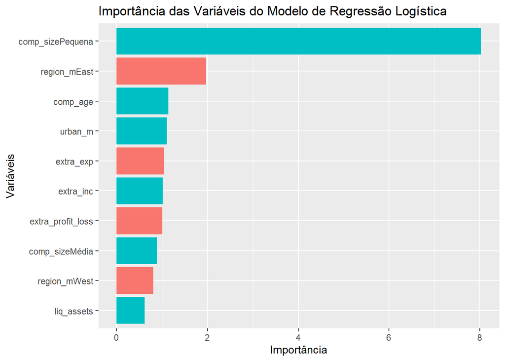

```r
vip(log, mapping = aes(fill = Sign)) + labs(title = "Importância das Variáveis do Modelo de Regressão Logística", x = "Variáveis", y = "Importância")
```

```r
dados_reduz <- subset(dados, select = -c(comp_size))
treino_reduz <- subset(treino, select = -c(comp_size))
teste_reduz <- subset(teste, select = -c(comp_size))
```

O primeiro modelo a ser estimado é o de regressão logística:

```r
log_reduz <- glm(will_close ~ ., data = treino_reduz, family = 'binomial')
summary(log_reduz)
```

```
##
## Call:
## glm(formula = will_close ~ ., family = "binomial", data = treino_reduz)
##
## Coefficients:
##                     Estimate Std. Error z value Pr(>|z|)
## (Intercept)       -3.649e+00  1.456e-01 -25.069  < 2e-16 ***
## amort              3.471e-07  1.074e-06   0.323 0.746547
## curr_assets       -1.194e-07  2.310e-07  -0.517 0.605266
## curr_liab          1.868e-08  1.387e-07   0.135 0.892900
## extra_exp         -3.168e-04  2.767e-04  -1.145 0.252318
## extra_inc          3.091e-04  2.765e-04   1.118 0.263728
## extra_profit_loss -3.077e-04  2.765e-04  -1.113 0.265713
## fixed_assets      -6.407e-08  1.962e-07  -0.327 0.744044
## inc_bef_tax        1.996e-08  3.310e-07   0.060 0.951908
## intang_assets     -9.244e-08  6.581e-07  -0.140 0.888298
## inventories        9.299e-08  2.609e-07   0.356 0.721543
## liq_assets         1.156e-07  2.094e-07   0.552 0.580945
## material_exp       2.467e-08  4.901e-08   0.503 0.614654
## personnel_exp     -2.491e-07  4.113e-07  -0.606 0.544762
## profit_loss_year   1.799e-07  5.575e-07   0.323 0.747019
## sales_x           -5.894e-07  1.717e-07  -3.434 0.000596 ***
## share_eq           4.867e-08  1.214e-07   0.401 0.688387
## subscribed_cap    -1.082e-08  1.161e-07  -0.093 0.925741
## tang_assets        2.032e-08  1.880e-07   0.108 0.913919
## urban_m            7.663e-02  6.286e-02   1.219 0.222793
## region_mEast      -2.692e-01  1.297e-01  -2.076 0.037925 *
## region_mWest      -1.243e-01  1.481e-01  -0.839 0.401466
## labor_avg          6.560e-03  5.027e-02   0.130 0.896178
## curr_idx_liq      -2.913e-06  8.175e-06  -0.356 0.721582
## comp_age           8.491e-03  6.806e-03   1.248 0.212191
## ---
## Signif. codes:  0 '***' 0.001 '**' 0.01 '*' 0.05 '.' 0.1 ' ' 1
##
## (Dispersion parameter for binomial family taken to be 1)
##
##     Null deviance: 4118.9  on 16835  degrees of freedom
## Residual deviance: 4084.9  on 16811  degrees of freedom
## AIC: 4134.9
##
## Number of Fisher Scoring iterations: 9
```

Agora, vamos aplicar o modelo de previsão nos dados de teste para estimar as probabilidades:

```r
prob_log_reduz <- predict(log_reduz, newdata = teste_reduz, type = "response")
```

E armazenar em um tibble os resultados das probabilidades obtidas pela regressão logística e a respectiva classe observada:

```r
desempenho <- desempenho %>%
  bind_rows(tibble(prob = prob_log_reduz,
                   classes = teste_reduz$will_close,
                   metodo = "logística sem comp_size"))
```

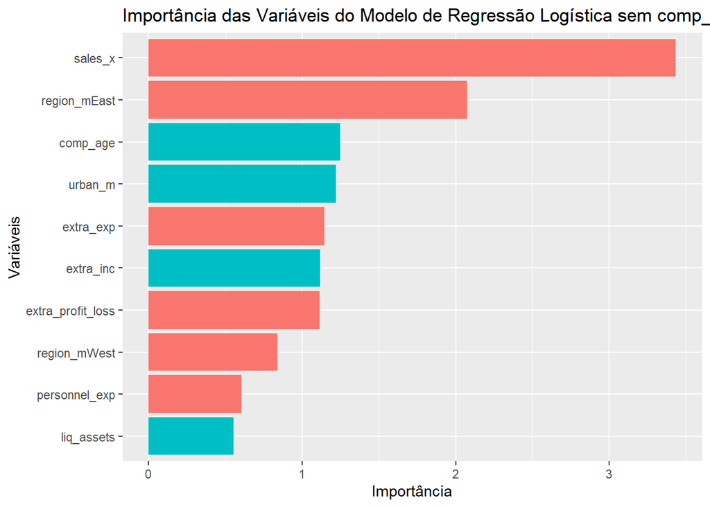

```r
vip(log_reduz, mapping = aes(fill = Sign)) +
  labs(title = "Importância das Variáveis do Modelo de Regressão Logística sem comp_size", x = "Variáveis", y = "Importância")
```

### Modelo Ridge

O próximo modelo a ser estimado é o Ridge. Primeiro, deverão ser preparadados os datasets de treinamento e teste para aplicação da função do pacote glmnet.

```r
X_treino <- model.matrix(will_close ~ ., dados)[idx,-1]
y_treino <- dados$will_close[idx]

X_teste <- model.matrix(will_close ~ ., dados)[-idx,-1]
y_teste <- dados$will_close[-idx]
```

Abaixo, foi criado o modelo Ridge e plotando o gráfico com os lambdas variando até 500:

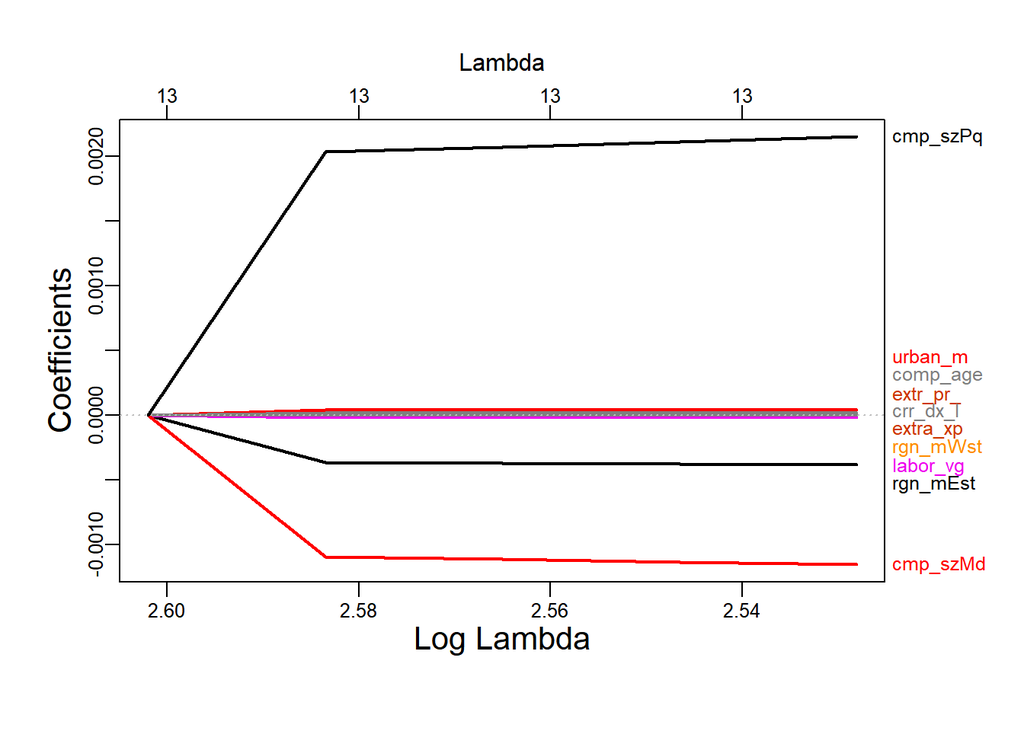

```r
ridge <- glmnet(X_treino, y_treino,  alpha = 0, nlambda = 500, family = "binomial")
plot_glmnet(ridge, lwd = 2, cex.lab = 1.3)
```

A seguir, vamos fazer a validação cruzada do modelo:

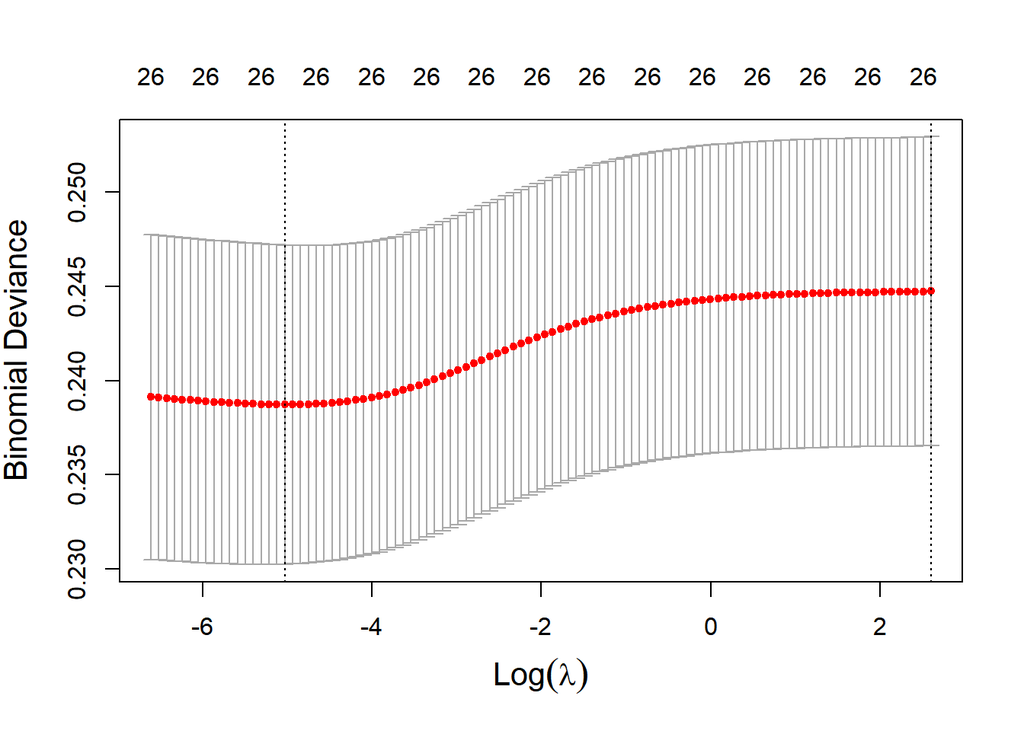

```r
cv_ridge <- cv.glmnet(X_treino, y_treino, alpha = 0, family = "binomial")
plot(cv_ridge, cex.lab = 1.3)
```

Vamos aplicar o modelo de previsão com base no melhor lambda (menor erro), estimando as probabilidades a partir da base de teste:

```r
prob_ridge <- predict(ridge, newx = X_teste, s = cv_ridge$lambda.min, type = "response")
```

E armazenar em um tibble os resultados das probabilidades obtidas pelo modelo Ridge e a respectiva classe observada:

```r
desempenho <- desempenho %>%
  bind_rows(tibble(prob = as.numeric(prob_ridge),
                   classes = y_teste,
                   metodo = "ridge"))
```

Abaixo, plotamos o gráfico com a importância de cada variável para esse modelo Rigde:

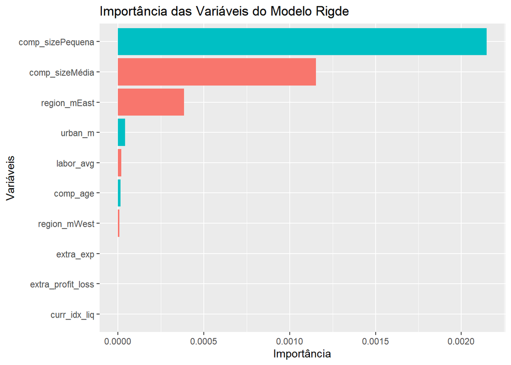

```r
vip(ridge, mapping = aes(fill = Sign)) + labs(title = "Importância das Variáveis do Modelo Rigde", x = "Variáveis", y = "Importância")
```

### Regressão LASSO

O modelo seguinte a ser criado é o LASSO. Assim como no modelo Ridge, foi criado o modelo LASSO e plotado o gráfico com os lambdas variando até 500:

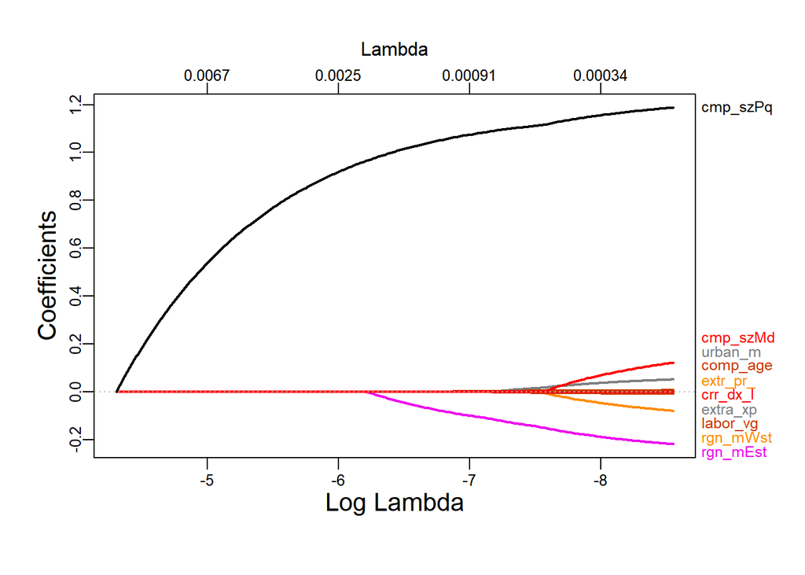

```r
lasso <- glmnet(X_treino, y_treino,  alpha = 1, nlambda = 500, family = "binomial")
plot_glmnet(lasso, lwd = 2, cex.lab = 1.3)
```

O próximo passo é fazer a validação cruzada do modelo:

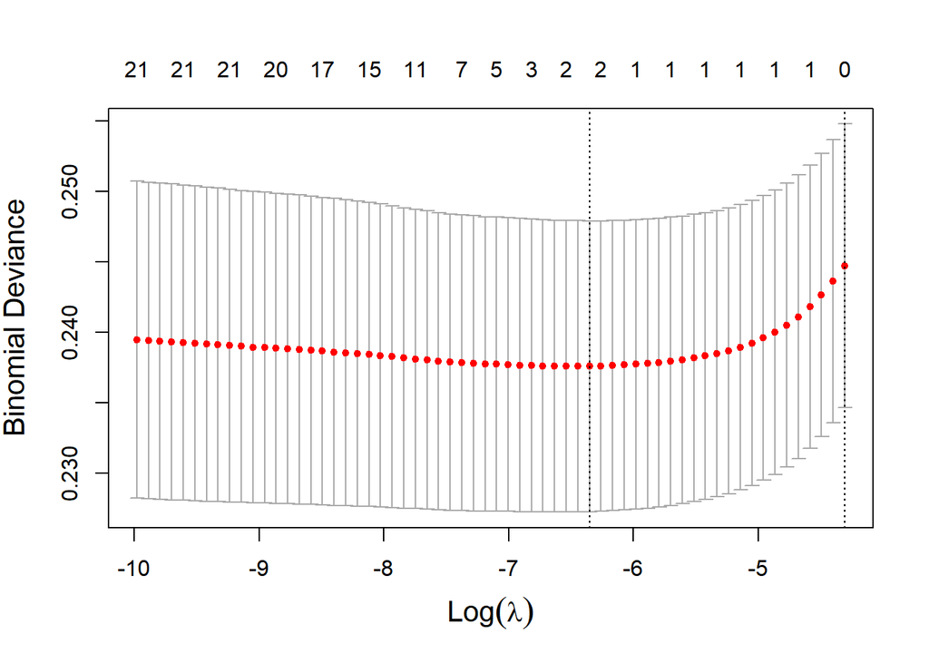

```r
cv_lasso <- cv.glmnet(X_treino, y_treino, alpha = 1, family = "binomial")
plot(cv_lasso, cex.lab = 1.3)
```

Agora, será aplicado o modelo de previsão com base no melhor lambda (menor erro), estimando as probabilidades a partir da base de teste:

```r
prob_lasso <- predict(lasso, newx = X_teste, s = cv_lasso$lambda.min, type = "response")
```

E armazenado em um tibble os resultados das probabilidades obtidas pelo modelo Lasso e a respectiva classe observada:

```r
desempenho <- desempenho %>%
  bind_rows(tibble(prob = as.numeric(prob_lasso),
                   classes = y_teste,
                   metodo = "lasso"))
```

Abaixo, foi plotado o gráfico com a importância de cada variável para esse modelo:

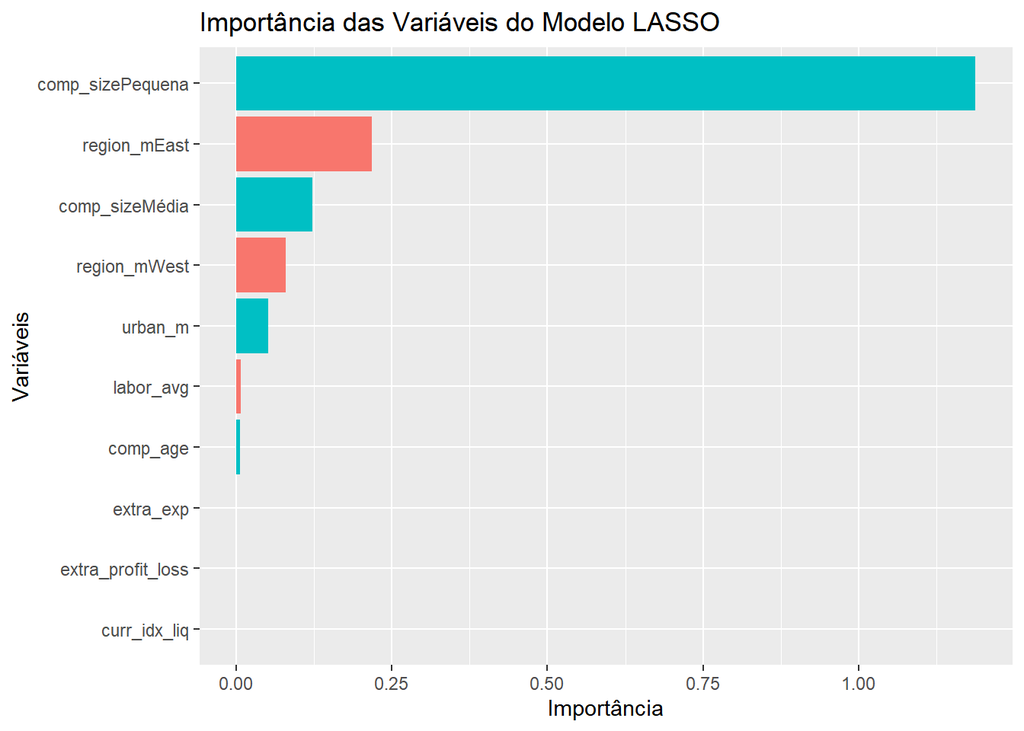

```r
vip(lasso, mapping = aes(fill = Sign)) + labs(title = "Importância das Variáveis do Modelo LASSO", x = "Variáveis", y = "Importância")
```

### Floresta Aleatória

O próximo modelo que será criado e testado é o de floresta aleatória com 500 árvores e com todas as variáveis:

```r
rf <- ranger(will_close ~ ., probability = TRUE, data = treino)
```

Para essa floresta aleatória com 500 árvores e com todas as variáveis, vamos fazer a previsão a partir dos dados de teste:

```r
prob_rf <- predict(rf, teste)$predictions[,2]
```

E armazenando em um tibble os resultados das probabilidades obtidas pelo modelo de floresta aleatória e a respectiva classe observada:

```r
desempenho <- desempenho %>%
  bind_rows(tibble(prob = prob_rf,
                   classes = teste$will_close,
                   metodo = "floresta aleatória"))
```

Abaixo, plotamos o gráfico com a importância de cada variável para esse modelo de floresta aleatória:

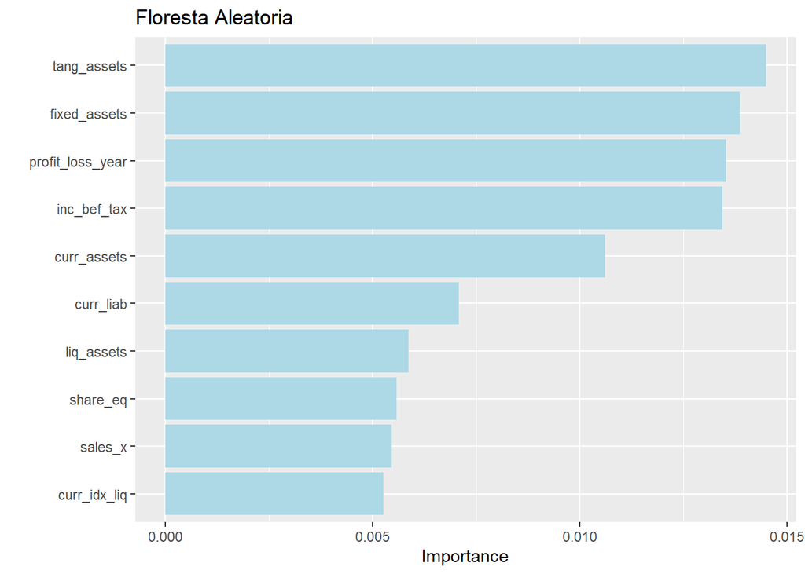

```r
vip(ranger(will_close ~ ., probability = TRUE, importance = "permutation", data = dados), aesthetics = list(fill = "lightblue")) + labs(title = "Floresta Aleatoria")
```

Agora, vamos iterar para testar o número de árvores de 1 a 500, bem como o número de variáveis por split, plotar o resultado dessa iteração:

```r
result_arvores <- crossing(mtry = c(2, 4, 8, 12, 16, 20, 23), #número de variáveis por split a ser testados
                       n_arvores = c(1:10, seq(10, 500, 10)))
itera <- function(mtry, n_arvores) {
  rf_itera <- ranger(will_close ~ ., probability = TRUE, num.trees = n_arvores, mtry = mtry, data = treino)
  return(rf_itera$prediction.error)
}
result_arvores <- result_arvores %>%
  mutate(erro = map2_dbl(mtry, n_arvores, itera))
head(result_arvores)
```

```
## # A tibble: 6 × 3
##    mtry n_arvores   erro
##   <dbl>     <dbl>  <dbl>
## 1     2         1 0.0436
## 2     2         2 0.0374
## 3     2         3 0.0397
## 4     2         4 0.0376
## 5     2         5 0.0356
## 6     2         6 0.0352
```

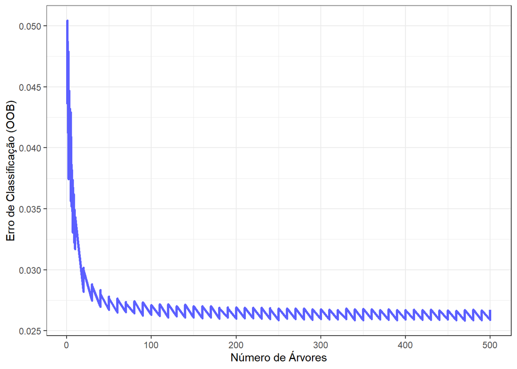

```r
result_arvores %>% ggplot(aes(n_arvores, erro)) +
 geom_line(color = "#5B5FFF", size = 1.2) +
 labs(x = "Número de Árvores", y = "Erro de Classificação (OOB)") +
 theme_bw()
```

A partir da iteração acima, vamos obter os dados da floresta ótima (número de árvores e número de variáveis por split) com o menor erro:

```r
floresta_otima <- result_arvores %>% as_tibble() %>% filter(erro== min(erro))#Obtendo dados da floresta ótima
mtry_otimo <- floresta_otima$mtry #numero de arvores para floresta otima
n_arvores_otimo <- floresta_otima$n_arvores # variaveis por split
```

E criar o modelo de floresta aleatória ótima:

```r
rf_otima <- ranger(will_close ~ ., probability = TRUE, num.trees = n_arvores_otimo,
                   mtry = mtry_otimo, data = treino)
```

Para essa floresta aleatória ótima, vamos fazer a previsão a partir dos dados de teste:

```r
prob_rf_otima <- predict(rf_otima, teste)$predictions[,2]
```

```r
desempenho <- desempenho %>%
  bind_rows(tibble(prob = prob_rf_otima,
                   classes = teste$will_close,
                   metodo = "floresta aleatória ótima"))
```

Abaixo, plotamos o gráfico com a importância de cada variável para esse modelo de floresta aleatória otimizada:

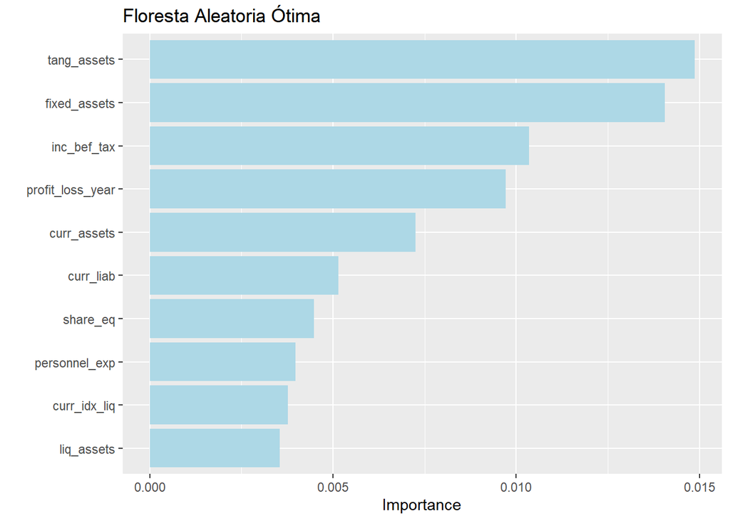

```r
vip(ranger(will_close ~ ., probability = TRUE, importance = "permutation", num.trees = n_arvores_otimo, mtry = mtry_otimo, data = treino),
    aesthetics = list(fill = "lightblue")) + labs(title = "Floresta Aleatoria Ótima")
```

### Boosting

O último modelo que será criado e testado nesse ciclo de modelagem é o Boosting com 500 árvores e taxa de aprendizagem 0,05:

```r
(fit_bst <- gbm(will_close ~ ., distribution = "bernoulli", n.trees = 500,
                interaction.depth = 4, shrinkage = 0.05, data = treino))
```

```
## gbm(formula = will_close ~ ., distribution = "bernoulli", data = treino,
##     n.trees = 500, interaction.depth = 4, shrinkage = 0.05)
## A gradient boosted model with bernoulli loss function.
## 500 iterations were performed.
## There were 24 predictors of which 24 had non-zero influence.
```

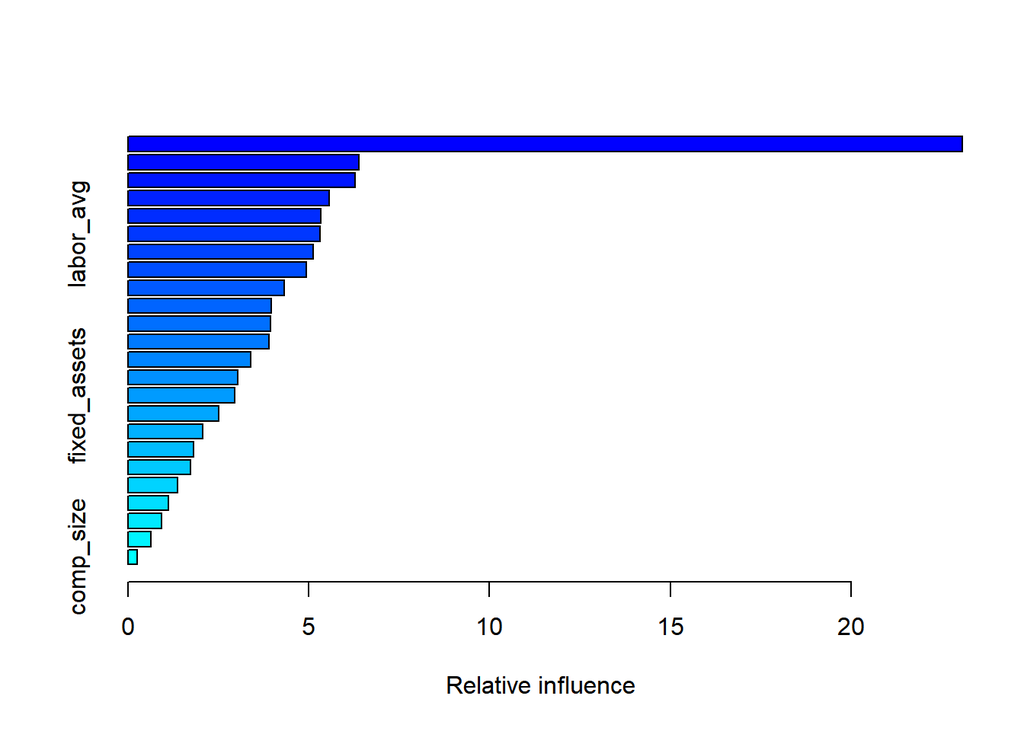

```
##                                 var    rel.inf
## sales_x                     sales_x 23.0726351
## curr_idx_liq           curr_idx_liq  6.3824939
## share_eq                   share_eq  6.2801635
## liq_assets               liq_assets  5.5590453
## curr_liab                 curr_liab  5.3354103
## labor_avg                 labor_avg  5.3224156
## inc_bef_tax             inc_bef_tax  5.1170821
## personnel_exp         personnel_exp  4.9321255
## material_exp           material_exp  4.3194465
## inventories             inventories  3.9645497
## curr_assets             curr_assets  3.9335307
## amort                         amort  3.9000950
## profit_loss_year   profit_loss_year  3.4044400
## comp_age                   comp_age  3.0390210
## fixed_assets           fixed_assets  2.9610098
## subscribed_cap       subscribed_cap  2.5087791
## extra_inc                 extra_inc  2.0746223
## extra_profit_loss extra_profit_loss  1.8193467
## tang_assets             tang_assets  1.7403115
## intang_assets         intang_assets  1.3699979
## urban_m                     urban_m  1.1272849
## region_m                   region_m  0.9337623
## extra_exp                 extra_exp  0.6437315
## comp_size                 comp_size  0.2586998
```

```r
summary(fit_bst)
```

O passo seguinte é fazer a validação cruzadas do modelo para obter o número de árvores ótimo:

```r
fit_cv <- gbm(will_close ~ ., data = treino, cv.folds = 5, n.trees = 500,
              interaction.depth = 4, distribution = "bernoulli", shrinkage = 0.05)

num_arv_boost <- gbm.perf(fit_cv, method = "cv") #obtendo a árvore ótima
```

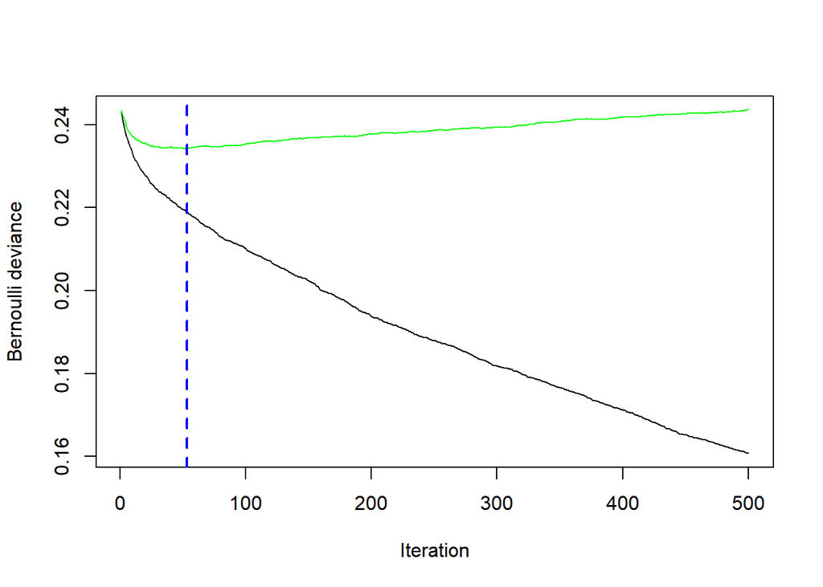

Aplicando o modelo de previsão com base na melhor quantidade de árvores (menor erro) e estimando as probabilidades a partir da base de teste, temos:

```r
prob_gbm <- predict(fit_cv, teste, n.trees = num_arv_boost, type = "response")
```

```r
desempenho <- desempenho %>%
  bind_rows(tibble(prob = prob_gbm,
                   classes = teste$will_close,
                   metodo = "boosting"))
```

### Regressão logística com stepwise

Após estimar os cincos modelos acima, vamos verificar se a redução de variáveis para o modelo de regressão logística melhora o desempenho deste. Para tal, será utilizado o método stepwise. Assim, vamos selecionar primeiro as variáveis a serem utilizadas por meio do método stepwise:

```r
modelo_stepAIC <- stepAIC(log, direction = "both")
```

```
## Start:  AIC=4035.62
## will_close ~ amort + curr_assets + curr_liab + extra_exp + extra_inc +
##     extra_profit_loss + fixed_assets + inc_bef_tax + intang_assets +
##     inventories + liq_assets + material_exp + personnel_exp +
##     profit_loss_year + sales_x + share_eq + subscribed_cap +
##     tang_assets + urban_m + region_m + labor_avg + curr_idx_liq +
##     comp_age + comp_size
```

[output not shown]

```
##                     Df Deviance    AIC
## - labor_avg          1   3981.6 4033.6
## - subscribed_cap     1   3981.6 4033.6
## - curr_liab          1   3981.6 4033.6
## - inc_bef_tax        1   3981.6 4033.6
## - intang_assets      1   3981.6 4033.6
## - sales_x            1   3981.6 4033.6
## - amort              1   3981.7 4033.7
## - profit_loss_year   1   3981.7 4033.7
## - tang_assets        1   3981.7 4033.7
## - inventories        1   3981.7 4033.7
## - material_exp       1   3981.8 4033.8
## - share_eq           1   3981.8 4033.8
## - curr_idx_liq       1   3981.8 4033.8
## - curr_assets        1   3981.8 4033.8
## - personnel_exp      1   3981.9 4033.9
## - fixed_assets       1   3981.9 4033.9
## - liq_assets         1   3982.0 4034.0
## - extra_profit_loss  1   3982.4 4034.4
## - extra_inc          1   3982.4 4034.4
## - extra_exp          1   3982.4 4034.4
## - urban_m            1   3982.9 4034.9
## - comp_age           1   3982.9 4034.9
## - region_m           2   3985.6 4035.6
## <none>                   3981.6 4035.6
## - comp_size          2   4084.9 4134.9
```

```
##
## Step:  AIC=4033.63
## will_close ~ amort + curr_assets + curr_liab + extra_exp + extra_inc +
##     extra_profit_loss + fixed_assets + inc_bef_tax + intang_assets +
##     inventories + liq_assets + material_exp + personnel_exp +
##     profit_loss_year + sales_x + share_eq + subscribed_cap +
##     tang_assets + urban_m + region_m + curr_idx_liq + comp_age +
##     comp_size
```

[output not shown]

```
##                     Df Deviance    AIC
## - subscribed_cap     1   3981.6 4031.6
## - curr_liab          1   3981.6 4031.6
## - inc_bef_tax        1   3981.6 4031.6
## - intang_assets      1   3981.6 4031.6
## - sales_x            1   3981.7 4031.7
## - amort              1   3981.7 4031.7
## - profit_loss_year   1   3981.7 4031.7
## - tang_assets        1   3981.7 4031.7
## - inventories        1   3981.7 4031.7
## - material_exp       1   3981.8 4031.8
## - share_eq           1   3981.8 4031.8
## - curr_idx_liq       1   3981.8 4031.8
## - curr_assets        1   3981.8 4031.8
## - fixed_assets       1   3981.9 4031.9
## - liq_assets         1   3982.0 4032.0
## - personnel_exp      1   3982.2 4032.2
## - extra_profit_loss  1   3982.4 4032.4
## - extra_inc          1   3982.4 4032.4
## - extra_exp          1   3982.4 4032.4
## - urban_m            1   3982.9 4032.9
## - comp_age           1   3982.9 4032.9
## - region_m           2   3985.6 4033.6
## <none>                   3981.6 4033.6
## + labor_avg          1   3981.6 4035.6
## - comp_size          2   4084.9 4132.9
```

```
##
## Step:  AIC=4031.63
## will_close ~ amort + curr_assets + curr_liab + extra_exp + extra_inc +
##     extra_profit_loss + fixed_assets + inc_bef_tax + intang_assets +
##     inventories + liq_assets + material_exp + personnel_exp +
##     profit_loss_year + sales_x + share_eq + tang_assets + urban_m +
##     region_m + curr_idx_liq + comp_age + comp_size
```

[output not shown]

```
##                     Df Deviance    AIC
## - curr_liab          1   3981.6 4029.6
## - inc_bef_tax        1   3981.6 4029.6
## - intang_assets      1   3981.6 4029.6
## - sales_x            1   3981.7 4029.7
## - amort              1   3981.7 4029.7
## - profit_loss_year   1   3981.7 4029.7
## - tang_assets        1   3981.7 4029.7
## - inventories        1   3981.8 4029.8
## - material_exp       1   3981.8 4029.8
## - curr_idx_liq       1   3981.8 4029.8
## - share_eq           1   3981.8 4029.8
## - curr_assets        1   3981.9 4029.9
## - fixed_assets       1   3981.9 4029.9
## - liq_assets         1   3982.0 4030.0
## - personnel_exp      1   3982.2 4030.2
## - extra_profit_loss  1   3982.4 4030.4
## - extra_inc          1   3982.4 4030.4
## - extra_exp          1   3982.4 4030.4
## - urban_m            1   3982.9 4030.9
## - comp_age           1   3982.9 4030.9
## - region_m           2   3985.6 4031.6
## <none>                   3981.6 4031.6
## + subscribed_cap     1   3981.6 4033.6
## + labor_avg          1   3981.6 4033.6
## - comp_size          2   4084.9 4130.9
```

```
##
## Step:  AIC=4029.64
## will_close ~ amort + curr_assets + extra_exp + extra_inc + extra_profit_loss +
##     fixed_assets + inc_bef_tax + intang_assets + inventories +
##     liq_assets + material_exp + personnel_exp + profit_loss_year +
##     sales_x + share_eq + tang_assets + urban_m + region_m + curr_idx_liq +
##     comp_age + comp_size
```

[output not shown]

```
##                     Df Deviance    AIC
## - inc_bef_tax        1   3981.6 4027.6
## - intang_assets      1   3981.7 4027.7
## - sales_x            1   3981.7 4027.7
## - amort              1   3981.7 4027.7
## - profit_loss_year   1   3981.7 4027.7
## - tang_assets        1   3981.7 4027.7
## - inventories        1   3981.8 4027.8
## - material_exp       1   3981.8 4027.8
## - curr_idx_liq       1   3981.8 4027.8
## - curr_assets        1   3981.9 4027.9
## - share_eq           1   3982.0 4028.0
## - liq_assets         1   3982.0 4028.0
## - fixed_assets       1   3982.1 4028.1
## - personnel_exp      1   3982.2 4028.2
## - extra_profit_loss  1   3982.4 4028.4
## - extra_inc          1   3982.4 4028.4
## - extra_exp          1   3982.4 4028.4
## - urban_m            1   3982.9 4028.9
## - comp_age           1   3982.9 4028.9
## - region_m           2   3985.6 4029.6
## <none>                   3981.6 4029.6
## + curr_liab          1   3981.6 4031.6
## + subscribed_cap     1   3981.6 4031.6
## + labor_avg          1   3981.6 4031.6
## - comp_size          2   4084.9 4128.9
```

```
##
## Step:  AIC=4027.65
## will_close ~ amort + curr_assets + extra_exp + extra_inc + extra_profit_loss +
##     fixed_assets + intang_assets + inventories + liq_assets +
##     material_exp + personnel_exp + profit_loss_year + sales_x +
##     share_eq + tang_assets + urban_m + region_m + curr_idx_liq +
##     comp_age + comp_size
```

[output not shown]

```
##                     Df Deviance    AIC
## - intang_assets      1   3981.7 4025.7
## - sales_x            1   3981.7 4025.7
## - amort              1   3981.7 4025.7
## - tang_assets        1   3981.7 4025.7
## - inventories        1   3981.8 4025.8
## - material_exp       1   3981.8 4025.8
## - profit_loss_year   1   3981.8 4025.8
## - curr_idx_liq       1   3981.8 4025.8
## - curr_assets        1   3982.0 4026.0
## - share_eq           1   3982.0 4026.0
## - liq_assets         1   3982.0 4026.0
## - fixed_assets       1   3982.1 4026.1
## - personnel_exp      1   3982.2 4026.2
## - extra_profit_loss  1   3982.4 4026.4
## - extra_inc          1   3982.4 4026.4
## - extra_exp          1   3982.5 4026.5
## - urban_m            1   3982.9 4026.9
## - comp_age           1   3982.9 4026.9
## - region_m           2   3985.6 4027.6
## <none>                   3981.6 4027.6
## + inc_bef_tax        1   3981.6 4029.6
## + curr_liab          1   3981.6 4029.6
## + subscribed_cap     1   3981.6 4029.6
## + labor_avg          1   3981.6 4029.6
## - comp_size          2   4084.9 4126.9
```

```
##
## Step:  AIC=4025.67
## will_close ~ amort + curr_assets + extra_exp + extra_inc + extra_profit_loss +
##     fixed_assets + inventories + liq_assets + material_exp +
##     personnel_exp + profit_loss_year + sales_x + share_eq + tang_assets +
##     urban_m + region_m + curr_idx_liq + comp_age + comp_size
```

[output not shown]

```
##                     Df Deviance    AIC
## - sales_x            1   3981.7 4023.7
## - amort              1   3981.7 4023.7
## - inventories        1   3981.8 4023.8
## - material_exp       1   3981.8 4023.8
## - tang_assets        1   3981.8 4023.8
## - profit_loss_year   1   3981.8 4023.8
## - curr_idx_liq       1   3981.9 4023.9
## - curr_assets        1   3982.0 4024.0
## - share_eq           1   3982.0 4024.0
## - liq_assets         1   3982.1 4024.1
## - personnel_exp      1   3982.2 4024.2
## - fixed_assets       1   3982.4 4024.4
## - extra_profit_loss  1   3982.4 4024.4
## - extra_inc          1   3982.4 4024.4
## - extra_exp          1   3982.5 4024.5
## - urban_m            1   3982.9 4024.9
## - comp_age           1   3983.0 4025.0
## - region_m           2   3985.7 4025.7
## <none>                   3981.7 4025.7
## + intang_assets      1   3981.6 4027.6
## + inc_bef_tax        1   3981.7 4027.7
## + curr_liab          1   3981.7 4027.7
## + labor_avg          1   3981.7 4027.7
## + subscribed_cap     1   3981.7 4027.7
## - comp_size          2   4084.9 4124.9
```

```
##
## Step:  AIC=4023.7
## will_close ~ amort + curr_assets + extra_exp + extra_inc + extra_profit_loss +
##     fixed_assets + inventories + liq_assets + material_exp +
##     personnel_exp + profit_loss_year + share_eq + tang_assets +
##     urban_m + region_m + curr_idx_liq + comp_age + comp_size
```

[output not shown]

```
##                     Df Deviance    AIC
## - amort              1   3981.7 4021.7
## - inventories        1   3981.8 4021.8
## - material_exp       1   3981.8 4021.8
## - tang_assets        1   3981.9 4021.9
## - profit_loss_year   1   3981.9 4021.9
## - curr_idx_liq       1   3981.9 4021.9
## - curr_assets        1   3982.0 4022.0
## - share_eq           1   3982.1 4022.1
## - liq_assets         1   3982.1 4022.1
## - personnel_exp      1   3982.2 4022.2
## - fixed_assets       1   3982.4 4022.4
## - extra_profit_loss  1   3982.5 4022.5
## - extra_inc          1   3982.5 4022.5
## - extra_exp          1   3982.5 4022.5
## - urban_m            1   3982.9 4022.9
## - comp_age           1   3983.0 4023.0
## - region_m           2   3985.7 4023.7
## <none>                   3981.7 4023.7
## + sales_x            1   3981.7 4025.7
## + intang_assets      1   3981.7 4025.7
## + inc_bef_tax        1   3981.7 4025.7
## + curr_liab          1   3981.7 4025.7
## + labor_avg          1   3981.7 4025.7
## + subscribed_cap     1   3981.7 4025.7
## - comp_size          2   4107.8 4145.8
```

```
##
## Step:  AIC=4021.73
## will_close ~ curr_assets + extra_exp + extra_inc + extra_profit_loss +
##     fixed_assets + inventories + liq_assets + material_exp +
##     personnel_exp + profit_loss_year + share_eq + tang_assets +
##     urban_m + region_m + curr_idx_liq + comp_age + comp_size
```

[output not shown]

```
##                     Df Deviance    AIC
## - inventories        1   3981.8 4019.8
## - profit_loss_year   1   3981.9 4019.9
## - material_exp       1   3981.9 4019.9
## - curr_idx_liq       1   3981.9 4019.9
## - tang_assets        1   3982.1 4020.1
## - curr_assets        1   3982.1 4020.1
## - share_eq           1   3982.2 4020.2
## - personnel_exp      1   3982.2 4020.2
## - liq_assets         1   3982.3 4020.3
## - extra_profit_loss  1   3982.5 4020.5
## - extra_inc          1   3982.5 4020.5
## - extra_exp          1   3982.6 4020.6
## - fixed_assets       1   3982.6 4020.6
## - urban_m            1   3983.0 4021.0
## - comp_age           1   3983.0 4021.0
## <none>                   3981.7 4021.7
## - region_m           2   3985.7 4021.7
## + amort              1   3981.7 4023.7
## + sales_x            1   3981.7 4023.7
## + inc_bef_tax        1   3981.7 4023.7
## + curr_liab          1   3981.7 4023.7
## + intang_assets      1   3981.7 4023.7
## + labor_avg          1   3981.7 4023.7
## + subscribed_cap     1   3981.7 4023.7
## - comp_size          2   4107.9 4143.9
```

```
##
## Step:  AIC=4019.84
## will_close ~ curr_assets + extra_exp + extra_inc + extra_profit_loss +
##     fixed_assets + liq_assets + material_exp + personnel_exp +
##     profit_loss_year + share_eq + tang_assets + urban_m + region_m +
##     curr_idx_liq + comp_age + comp_size
```

[output not shown]

```
##                     Df Deviance    AIC
## - profit_loss_year   1   3982.0 4018.0
## - material_exp       1   3982.0 4018.0
## - curr_idx_liq       1   3982.1 4018.1
## - curr_assets        1   3982.1 4018.1
## - tang_assets        1   3982.2 4018.2
## - liq_assets         1   3982.3 4018.3
## - share_eq           1   3982.3 4018.3
## - personnel_exp      1   3982.4 4018.4
## - extra_profit_loss  1   3982.6 4018.6
## - extra_inc          1   3982.6 4018.6
## - extra_exp          1   3982.7 4018.7
## - fixed_assets       1   3982.8 4018.8
## - urban_m            1   3983.1 4019.1
## - comp_age           1   3983.1 4019.1
## <none>                   3981.8 4019.8
## - region_m           2   3985.8 4019.8
## + inventories        1   3981.7 4021.7
## + amort              1   3981.8 4021.8
## + sales_x            1   3981.8 4021.8
## + curr_liab          1   3981.8 4021.8
## + intang_assets      1   3981.8 4021.8
## + subscribed_cap     1   3981.8 4021.8
## + inc_bef_tax        1   3981.8 4021.8
## + labor_avg          1   3981.8 4021.8
## - comp_size          2   4108.1 4142.1
```

```
##
## Step:  AIC=4017.98
## will_close ~ curr_assets + extra_exp + extra_inc + extra_profit_loss +
##     fixed_assets + liq_assets + material_exp + personnel_exp +
##     share_eq + tang_assets + urban_m + region_m + curr_idx_liq +
##     comp_age + comp_size
```

[output not shown]

```
##                     Df Deviance    AIC
## - material_exp       1   3982.2 4016.2
## - curr_idx_liq       1   3982.2 4016.2
## - curr_assets        1   3982.3 4016.3
## - tang_assets        1   3982.5 4016.5
## - personnel_exp      1   3982.5 4016.5
## - liq_assets         1   3982.5 4016.5
## - share_eq           1   3982.7 4016.7
## - extra_profit_loss  1   3982.8 4016.8
## - extra_inc          1   3982.8 4016.8
## - extra_exp          1   3982.8 4016.8
## - fixed_assets       1   3983.2 4017.2
## - urban_m            1   3983.2 4017.2
## - comp_age           1   3983.3 4017.3
## - region_m           2   3986.0 4018.0
## <none>                   3982.0 4018.0
## + profit_loss_year   1   3981.8 4019.8
## + inventories        1   3981.9 4019.9
## + inc_bef_tax        1   3981.9 4019.9
## + subscribed_cap     1   3982.0 4020.0
## + sales_x            1   3982.0 4020.0
## + intang_assets      1   3982.0 4020.0
## + amort              1   3982.0 4020.0
## + curr_liab          1   3982.0 4020.0
## + labor_avg          1   3982.0 4020.0
## - comp_size          2   4108.2 4140.2
```

```
##
## Step:  AIC=4016.19
## will_close ~ curr_assets + extra_exp + extra_inc + extra_profit_loss +
##     fixed_assets + liq_assets + personnel_exp + share_eq + tang_assets +
##     urban_m + region_m + curr_idx_liq + comp_age + comp_size
```

[output not shown]

```
##                     Df Deviance    AIC
## - curr_assets        1   3982.3 4014.3
## - curr_idx_liq       1   3982.4 4014.4
## - personnel_exp      1   3982.6 4014.6
## - liq_assets         1   3982.7 4014.7
## - tang_assets        1   3982.7 4014.7
## - share_eq           1   3982.9 4014.9
## - extra_profit_loss  1   3983.0 4015.0
## - extra_inc          1   3983.0 4015.0
## - extra_exp          1   3983.0 4015.0
## - comp_age           1   3983.4 4015.4
## - urban_m            1   3983.5 4015.5
## - fixed_assets       1   3983.5 4015.5
## <none>                   3982.2 4016.2
## - region_m           2   3986.2 4016.2
## + material_exp       1   3982.0 4018.0
## + inventories        1   3982.0 4018.0
## + profit_loss_year   1   3982.0 4018.0
## + inc_bef_tax        1   3982.1 4018.1
## + sales_x            1   3982.2 4018.2
## + amort              1   3982.2 4018.2
## + subscribed_cap     1   3982.2 4018.2
## + intang_assets      1   3982.2 4018.2
## + curr_liab          1   3982.2 4018.2
## + labor_avg          1   3982.2 4018.2
## - comp_size          2   4108.6 4138.6
```

```
##
## Step:  AIC=4014.28
## will_close ~ extra_exp + extra_inc + extra_profit_loss + fixed_assets +
##     liq_assets + personnel_exp + share_eq + tang_assets + urban_m +
##     region_m + curr_idx_liq + comp_age + comp_size
```

[output not shown]

```
##                     Df Deviance    AIC
## - curr_idx_liq       1   3982.5 4012.5
## - liq_assets         1   3982.7 4012.7
## - tang_assets        1   3982.8 4012.8
## - share_eq           1   3982.9 4012.9
## - personnel_exp      1   3983.0 4013.0
## - extra_profit_loss  1   3983.0 4013.0
## - extra_inc          1   3983.1 4013.1
## - extra_exp          1   3983.1 4013.1
## - fixed_assets       1   3983.5 4013.5
## - comp_age           1   3983.5 4013.5
## - urban_m            1   3983.5 4013.5
## <none>                   3982.3 4014.3
## - region_m           2   3986.3 4014.3
## + profit_loss_year   1   3982.1 4016.1
## + curr_assets        1   3982.2 4016.2
## + curr_liab          1   3982.2 4016.2
## + subscribed_cap     1   3982.3 4016.3
## + inc_bef_tax        1   3982.3 4016.3
## + sales_x            1   3982.3 4016.3
## + amort              1   3982.3 4016.3
## + material_exp       1   3982.3 4016.3
## + intang_assets      1   3982.3 4016.3
## + labor_avg          1   3982.3 4016.3
## + inventories        1   3982.3 4016.3
## - comp_size          2   4108.7 4136.7
```

```
##
## Step:  AIC=4012.54
## will_close ~ extra_exp + extra_inc + extra_profit_loss + fixed_assets +
##     liq_assets + personnel_exp + share_eq + tang_assets + urban_m +
##     region_m + comp_age + comp_size
```

[output not shown]

```
##                     Df Deviance    AIC
## - liq_assets         1   3983.0 4011.0
## - tang_assets        1   3983.1 4011.1
## - share_eq           1   3983.1 4011.1
## - personnel_exp      1   3983.2 4011.2
## - extra_profit_loss  1   3983.3 4011.3
## - extra_inc          1   3983.3 4011.3
## - extra_exp          1   3983.4 4011.4
## - fixed_assets       1   3983.7 4011.7
## - comp_age           1   3983.8 4011.8
## - urban_m            1   3983.8 4011.8
## <none>                   3982.5 4012.5
## - region_m           2   3986.6 4012.6
## + curr_idx_liq       1   3982.3 4014.3
## + profit_loss_year   1   3982.4 4014.4
## + curr_assets        1   3982.4 4014.4
## + curr_liab          1   3982.5 4014.5
## + inc_bef_tax        1   3982.5 4014.5
## + amort              1   3982.5 4014.5
## + material_exp       1   3982.5 4014.5
## + subscribed_cap     1   3982.5 4014.5
## + sales_x            1   3982.5 4014.5
## + intang_assets      1   3982.5 4014.5
## + labor_avg          1   3982.5 4014.5
## + inventories        1   3982.5 4014.5
## - comp_size          2   4109.0 4135.0
```

```
##
## Step:  AIC=4010.97
## will_close ~ extra_exp + extra_inc + extra_profit_loss + fixed_assets +
##     personnel_exp + share_eq + tang_assets + urban_m + region_m +
##     comp_age + comp_size
```

[output not shown]

```
##                     Df Deviance    AIC
## - tang_assets        1   3983.5 4009.5
## - personnel_exp      1   3983.6 4009.6
## - extra_profit_loss  1   3983.7 4009.7
## - extra_inc          1   3983.7 4009.7
## - share_eq           1   3983.8 4009.8
## - extra_exp          1   3983.8 4009.8
## - fixed_assets       1   3984.1 4010.1
## - comp_age           1   3984.2 4010.2
## - urban_m            1   3984.3 4010.3
## <none>                   3983.0 4011.0
## - region_m           2   3987.0 4011.0
## + liq_assets         1   3982.5 4012.5
## + curr_idx_liq       1   3982.7 4012.7
## + profit_loss_year   1   3982.7 4012.7
## + amort              1   3982.8 4012.8
## + inc_bef_tax        1   3982.9 4012.9
## + material_exp       1   3982.9 4012.9
## + curr_assets        1   3982.9 4012.9
## + intang_assets      1   3982.9 4012.9
## + sales_x            1   3982.9 4012.9
## + curr_liab          1   3983.0 4013.0
## + inventories        1   3983.0 4013.0
## + labor_avg          1   3983.0 4013.0
## + subscribed_cap     1   3983.0 4013.0
## - comp_size          2   4109.3 4133.3
##
## Step:  AIC=4009.5
## will_close ~ extra_exp + extra_inc + extra_profit_loss + fixed_assets +
##     personnel_exp + share_eq + urban_m + region_m + comp_age +
##     comp_size
```

```
##                     Df Deviance    AIC
## - personnel_exp      1   3983.8 4007.8
## - share_eq           1   3984.0 4008.0
## - fixed_assets       1   3984.1 4008.1
## - extra_profit_loss  1   3984.3 4008.3
## - extra_inc          1   3984.3 4008.3
## - extra_exp          1   3984.3 4008.3
## - comp_age           1   3984.8 4008.8
## - urban_m            1   3984.8 4008.8
## <none>                   3983.5 4009.5
## - region_m           2   3987.6 4009.6
## + tang_assets        1   3983.0 4011.0
## + amort              1   3983.0 4011.0
## + liq_assets         1   3983.1 4011.1
## + profit_loss_year   1   3983.1 4011.1
## + curr_idx_liq       1   3983.3 4011.3
## + intang_assets      1   3983.4 4011.4
## + material_exp       1   3983.4 4011.4
## + inc_bef_tax        1   3983.4 4011.4
## + subscribed_cap     1   3983.5 4011.5
## + sales_x            1   3983.5 4011.5
## + labor_avg          1   3983.5 4011.5
## + inventories        1   3983.5 4011.5
## + curr_liab          1   3983.5 4011.5
## + curr_assets        1   3983.5 4011.5
## - comp_size          2   4109.7 4131.7
##
## Step:  AIC=4007.79
## will_close ~ extra_exp + extra_inc + extra_profit_loss + fixed_assets +
##     share_eq + urban_m + region_m + comp_age + comp_size
```

```
##                     Df Deviance    AIC
## - share_eq           1   3984.1 4006.1
## - fixed_assets       1   3984.4 4006.4
## - extra_profit_loss  1   3984.6 4006.6
## - extra_inc          1   3984.6 4006.6
## - extra_exp          1   3984.6 4006.6
## - comp_age           1   3985.0 4007.0
## - urban_m            1   3985.1 4007.1
## <none>                   3983.8 4007.8
## - region_m           2   3987.9 4007.9
## + liq_assets         1   3983.4 4009.4
## + personnel_exp      1   3983.5 4009.5
## + labor_avg          1   3983.5 4009.5
## + curr_idx_liq       1   3983.6 4009.6
## + profit_loss_year   1   3983.6 4009.6
## + tang_assets        1   3983.6 4009.6
## + intang_assets      1   3983.7 4009.7
## + curr_liab          1   3983.7 4009.7
## + curr_assets        1   3983.7 4009.7
## + subscribed_cap     1   3983.7 4009.7
## + inc_bef_tax        1   3983.7 4009.7
## + inventories        1   3983.7 4009.7
## + sales_x            1   3983.8 4009.8
## + material_exp       1   3983.8 4009.8
## + amort              1   3983.8 4009.8
## - comp_size          2   4110.2 4130.2
##
## Step:  AIC=4006.13
## will_close ~ extra_exp + extra_inc + extra_profit_loss + fixed_assets +
##     urban_m + region_m + comp_age + comp_size
```

```
##                     Df Deviance    AIC
## - fixed_assets       1   3984.5 4004.5
## - extra_profit_loss  1   3984.9 4004.9
## - extra_inc          1   3984.9 4004.9
## - extra_exp          1   3984.9 4004.9
## - comp_age           1   3985.3 4005.3
## - urban_m            1   3985.4 4005.4
## <none>                   3984.1 4006.1
## - region_m           2   3988.2 4006.2
## + liq_assets         1   3983.7 4007.7
## + profit_loss_year   1   3983.7 4007.7
## + share_eq           1   3983.8 4007.8
## + curr_idx_liq       1   3983.9 4007.9
## + labor_avg          1   3983.9 4007.9
## + personnel_exp      1   3984.0 4008.0
## + curr_liab          1   3984.0 4008.0
## + inc_bef_tax        1   3984.0 4008.0
## + tang_assets        1   3984.0 4008.0
## + intang_assets      1   3984.0 4008.0
## + amort              1   3984.1 4008.1
## + sales_x            1   3984.1 4008.1
## + subscribed_cap     1   3984.1 4008.1
## + material_exp       1   3984.1 4008.1
## + inventories        1   3984.1 4008.1
## + curr_assets        1   3984.1 4008.1
## - comp_size          2   4110.4 4128.4
##
## Step:  AIC=4004.46
## will_close ~ extra_exp + extra_inc + extra_profit_loss + urban_m +
##     region_m + comp_age + comp_size
```

```
##                     Df Deviance    AIC
## - extra_profit_loss  1   3985.2 4003.2
## - extra_inc          1   3985.2 4003.2
## - extra_exp          1   3985.3 4003.3
## - comp_age           1   3985.6 4003.6
## - urban_m            1   3985.8 4003.8
## <none>                   3984.5 4004.5
## - region_m           2   3988.5 4004.5
## + labor_avg          1   3984.1 4006.1
## + curr_liab          1   3984.1 4006.1
## + personnel_exp      1   3984.1 4006.1
## + fixed_assets       1   3984.1 4006.1
## + profit_loss_year   1   3984.2 4006.2
## + intang_assets      1   3984.2 4006.2
## + liq_assets         1   3984.2 4006.2
## + curr_idx_liq       1   3984.3 4006.3
## + subscribed_cap     1   3984.3 4006.3
## + curr_assets        1   3984.4 4006.4
## + tang_assets        1   3984.4 4006.4
## + share_eq           1   3984.4 4006.4
## + amort              1   3984.4 4006.4
## + inventories        1   3984.4 4006.4
## + sales_x            1   3984.4 4006.4
## + material_exp       1   3984.4 4006.4
## + inc_bef_tax        1   3984.5 4006.5
## - comp_size          2   4110.8 4126.8
##
## Step:  AIC=4003.22
## will_close ~ extra_exp + extra_inc + urban_m + region_m + comp_age +
##     comp_size
```

```
##                     Df Deviance    AIC
## - extra_inc          1   3985.4 4001.4
## - comp_age           1   3986.4 4002.4
## - urban_m            1   3986.5 4002.5
## - extra_exp          1   3986.9 4002.9
## <none>                   3985.2 4003.2
## - region_m           2   3989.3 4003.3
## + extra_profit_loss  1   3984.5 4004.5
## + labor_avg          1   3984.8 4004.8
## + curr_liab          1   3984.8 4004.8
## + personnel_exp      1   3984.8 4004.8
## + fixed_assets       1   3984.9 4004.9
## + profit_loss_year   1   3985.0 4005.0
## + intang_assets      1   3985.0 4005.0
## + liq_assets         1   3985.0 4005.0
## + curr_idx_liq       1   3985.0 4005.0
## + subscribed_cap     1   3985.0 4005.0
## + tang_assets        1   3985.1 4005.1
## + curr_assets        1   3985.1 4005.1
## + share_eq           1   3985.1 4005.1
## + amort              1   3985.2 4005.2
## + inventories        1   3985.2 4005.2
## + sales_x            1   3985.2 4005.2
## + material_exp       1   3985.2 4005.2
## + inc_bef_tax        1   3985.2 4005.2
## - comp_size          2   4111.6 4125.6
##
## Step:  AIC=4001.37
## will_close ~ extra_exp + urban_m + region_m + comp_age + comp_size
##
##                     Df Deviance    AIC
## - comp_age           1   3986.6 4000.6
## - urban_m            1   3986.7 4000.7
## - extra_exp          1   3987.0 4001.0
## <none>                   3985.4 4001.4
## - region_m           2   3989.4 4001.4
## + curr_liab          1   3985.1 4003.1
## + profit_loss_year   1   3985.1 4003.1
## + labor_avg          1   3985.1 4003.1
## + personnel_exp      1   3985.1 4003.1
```

[output cut: 94 more lines]

```
## + personnel_exp      1   3990.6 4000.6
## + urban_m            1   3990.7 4000.7
## + subscribed_cap     1   3990.7 4000.7
## + share_eq           1   3990.7 4000.7
## + sales_x            1   3990.7 4000.7
## + curr_assets        1   3990.7 4000.7
## + tang_assets        1   3990.7 4000.7
## + amort              1   3990.8 4000.8
## + inc_bef_tax        1   3990.8 4000.8
## + material_exp       1   3990.8 4000.8
## + inventories        1   3990.8 4000.8
## - comp_size          2   4117.6 4121.6
##
## Step:  AIC=3998.15
## will_close ~ comp_size
```

```
##                     Df Deviance    AIC
## <none>                   3992.1 3998.1
## + extra_exp          1   3990.8 3998.8
## + comp_age           1   3991.1 3999.1
## + region_m           2   3989.2 3999.2
## + curr_liab          1   3991.5 3999.5
## + labor_avg          1   3991.5 3999.5
## + extra_profit_loss  1   3991.6 3999.6
## + personnel_exp      1   3991.6 3999.6
## + fixed_assets       1   3991.7 3999.7
## + curr_assets        1   3991.9 3999.9
## + intang_assets      1   3991.9 3999.9
## + subscribed_cap     1   3991.9 3999.9
## + tang_assets        1   3992.0 4000.0
## + curr_idx_liq       1   3992.0 4000.0
## + share_eq           1   3992.0 4000.0
## + material_exp       1   3992.0 4000.0
## + inventories        1   3992.0 4000.0
## + urban_m            1   3992.0 4000.0
## + amort              1   3992.1 4000.1
## + profit_loss_year   1   3992.1 4000.1
## + extra_inc          1   3992.1 4000.1
## + inc_bef_tax        1   3992.1 4000.1
## + sales_x            1   3992.1 4000.1
## + liq_assets         1   3992.1 4000.1
## - comp_size          2   4118.9 4120.9
```

```r
lista_var <- append(attr(terms(modelo_stepAIC ), "term.labels"), "will_close")
dados_stepwise <- subset(dados, select = lista_var)
```

Após a seleção de variáveis, vamos criar os datasets de treino e teste:

```r
treino_stepwise <- subset(treino, select = lista_var)
teste_stepwise  <- subset(teste, select = lista_var)
```

Agora será estimado o modelo de regressão logística com stepwise:

```r
log_stepwise <- glm(will_close ~ ., data = treino_stepwise, family = "binomial")
summary(log_stepwise)
```

```
##
## Call:
## glm(formula = will_close ~ ., family = "binomial", data = treino_stepwise)
##
## Coefficients:
##                  Estimate Std. Error z value Pr(>|z|)
## (Intercept)       -4.4329     0.1257 -35.254   <2e-16 ***
## comp_sizeMédia     0.2017     0.2045   0.986    0.324
## comp_sizePequena   1.2442     0.1373   9.063   <2e-16 ***
## ---
## Signif. codes:  0 '***' 0.001 '**' 0.01 '*' 0.05 '.' 0.1 ' ' 1
##
## (Dispersion parameter for binomial family taken to be 1)
##
##     Null deviance: 4118.9  on 16835  degrees of freedom
## Residual deviance: 3992.1  on 16833  degrees of freedom
## AIC: 3998.1
##
## Number of Fisher Scoring iterations: 7
```

E aplicado o modelo de previsão com stepwise nos dados de teste para estimar as probabilidades:

```r
prob_log_stepwise <- predict(log_stepwise, newdata = teste_stepwise, type = "response")
```

Feito isso, vamos armazenar em um tibble os resultados das probabilidades obtidas pela regressão logística com stepwise e a respectiva classe observada:

```r
desempenho <- desempenho %>%
  bind_rows(tibble(prob = prob_log_stepwise,
                   classes = teste_stepwise$will_close,
                   metodo = "logística stepwise"))
```

Abaixo, foi plotado o gráfico com a importância de cada variável para esse modelo de regressão logística com redução de variáveis:

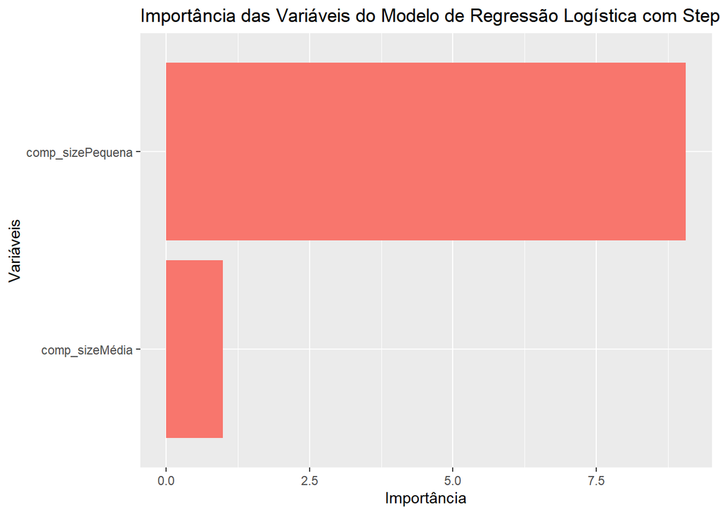

```r
vip(log_stepwise, mapping = aes(fill = Sign)) +
  labs(title = "Importância das Variáveis do Modelo de Regressão Logística com Stepwise", x = "Variáveis", y = "Importância")
```

### Regressão Logística sem Outliers

Durante o processo para estimar o modelo de regressão logística, foi feito um alerta que pode ser resultado no número elevado de outliers do dataset, conforme já apontado acima. Assim, vamos estimar o modelo de regressão logítica sem os outliers, utilizando o método de critério IQR (Intervalo Interquartil) para ver se o desempenho dos modelos melhoram.

Nesse caso, o primeiro caso é eliminar os outliers. Como os outliers estão concentrados no limite superior da coluna ‘sales’, vamos excluir somente esses valores.

```r
Q1 <- quantile(dados$sales_x, 0.25)
Q3 <- quantile(dados$sales_x, 0.75)
IQR <- Q3 - Q1

ls <- Q3 + 1.5 * IQR

dados_sem_outliers <- subset(dados, sales_x <= ls)
```

A etapa seguinte é criar os datasets de treinamento e teste, onde 80% do dataset será de treinamento:

```r
idx_sem_outliers <- sample(nrow(dados_sem_outliers), size = .80 * nrow(dados_sem_outliers), replace = FALSE)

treino_sem_outliers <- dados_sem_outliers[idx_sem_outliers,]
#teste_sem_outliers  <- dados_sem_outliers[-idx_sem_outliers,]
```

O primeiro modelo a ser estimado é o de regressão logística:

```r
log_sem_outliers <- glm(will_close ~ ., data = treino_sem_outliers, family = 'binomial')
```

```
## Warning: glm.fit: probabilidades ajustadas numericamente 0 ou 1 ocorreu
```

```r
summary(log_sem_outliers)
```

```
##
## Call:
## glm(formula = will_close ~ ., family = "binomial", data = treino_sem_outliers)
##
## Coefficients:
##                     Estimate Std. Error z value Pr(>|z|)
## (Intercept)       -3.076e+00  4.597e-01  -6.691 2.21e-11 ***
## amort              8.419e-07  1.098e-06   0.767 0.443077
## curr_assets       -1.875e-07  3.104e-07  -0.604 0.545832
## curr_liab         -7.041e-08  1.639e-07  -0.430 0.667551
## extra_exp         -2.807e-04  2.752e-04  -1.020 0.307611
## extra_inc          2.761e-04  2.750e-04   1.004 0.315441
## extra_profit_loss -2.758e-04  2.750e-04  -1.003 0.315876
## fixed_assets      -1.321e-08  1.342e-07  -0.098 0.921626
## inc_bef_tax        2.739e-07  4.979e-07   0.550 0.582291
## intang_assets      2.982e-08  1.678e-07   0.178 0.858932
## inventories        3.166e-07  3.700e-07   0.856 0.392155
## liq_assets         3.277e-07  3.333e-07   0.983 0.325569
## material_exp      -1.445e-08  8.083e-08  -0.179 0.858072
## personnel_exp     -2.983e-07  4.946e-07  -0.603 0.546417
## profit_loss_year  -1.985e-07  7.984e-07  -0.249 0.803650
## sales_x           -9.871e-06  2.628e-06  -3.756 0.000173 ***
## share_eq           9.140e-09  1.183e-07   0.077 0.938399
## subscribed_cap    -4.328e-08  1.227e-07  -0.353 0.724375
## tang_assets       -2.917e-08  1.294e-07  -0.225 0.821615
## urban_m            1.065e-01  6.697e-02   1.591 0.111700
## region_mEast      -2.777e-01  1.371e-01  -2.026 0.042815 *
## region_mWest      -1.849e-01  1.578e-01  -1.171 0.241474
## labor_avg          2.082e-02  5.106e-02   0.408 0.683433
## curr_idx_liq      -4.389e-06  1.075e-05  -0.408 0.683097
## comp_age           9.275e-03  7.269e-03   1.276 0.201994
## comp_sizeMédia    -7.563e-01  3.250e-01  -2.327 0.019953 *
## comp_sizePequena  -1.917e-01  3.962e-01  -0.484 0.628374
## ---
## Signif. codes:  0 '***' 0.001 '**' 0.01 '*' 0.05 '.' 0.1 ' ' 1
##
## (Dispersion parameter for binomial family taken to be 1)
##
##     Null deviance: 3627.5  on 14665  degrees of freedom
## Residual deviance: 3499.7  on 14639  degrees of freedom
## AIC: 3553.7
##
## Number of Fisher Scoring iterations: 10
```

A aplicação da função glm do R gerou o alerta (“warning”) a seguir: “Warning: glm.fit: probabilidades ajustadas numericamente 0 ou 1 ocorreu”. Esse alerta pode ser causado por outliers. Para tentar mitigar esse problema, vamos posteriormente dividir o dataset de acordo com o porte da empresa e estimar o modelo de regressão logística para cada um dos porte. Por ora, vamos continuar na estimativa e avaliação dos 5 modelos descritos acima.

Agora, vamos aplicar o modelo de previsão nos dados de teste para estimar as probabilidades:

```r
prob_log_sem_outliers <- predict(log_sem_outliers, newdata = teste, type = "response")
```

E armazenar em um tibble os resultados das probabilidades obtidas pela regressão logística e a respectiva classe observada:

```r
desempenho <- desempenho %>%
  bind_rows(tibble(prob = prob_log_sem_outliers,
                   classes = teste$will_close,
                   metodo = "logística sem outliers"))
```

Abaixo, foi plotado o gráfico com a importância de cada variável para esse modelo:

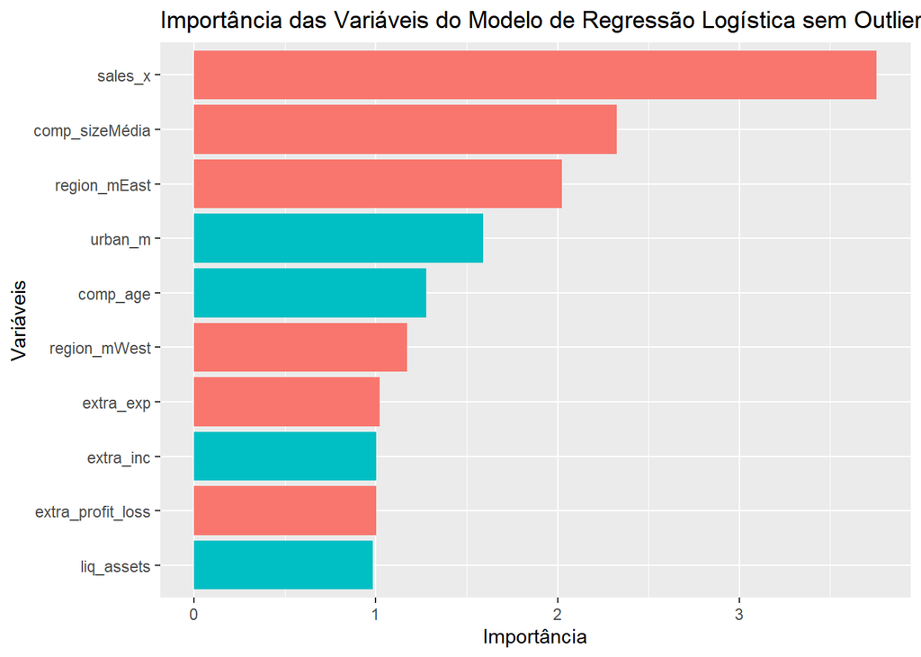

```r
vip(log_sem_outliers, mapping = aes(fill = Sign)) +
  labs(title = "Importância das Variáveis do Modelo de Regressão Logística sem Outliers", x = "Variáveis", y = "Importância")
```

### Modelo Ridge sem Outliers

O próximo modelo a ser estimado sem os outliers é o Ridge. Assim como foi feito no modelo ridge anterior, deverão ser preparadados os datasets de treinamento e teste para aplicação da função do pacote glmnet.

```r
X_treino_sem_outliers <- model.matrix(will_close ~ ., dados_sem_outliers)[idx_sem_outliers,-1]
y_treino_sem_outliers <- dados_sem_outliers$will_close[idx_sem_outliers]

#X_teste_sem_outliers <- model.matrix(will_close ~ ., dados_sem_outliers)[-idx_sem_outliers,-1]
#y_teste_sem_outliers <- dados_sem_outliers$will_close[-idx_sem_outliers]
```

Abaixo, foi criado o modelo Ridge e plotando o gráfico com os lambdas variando até 500:

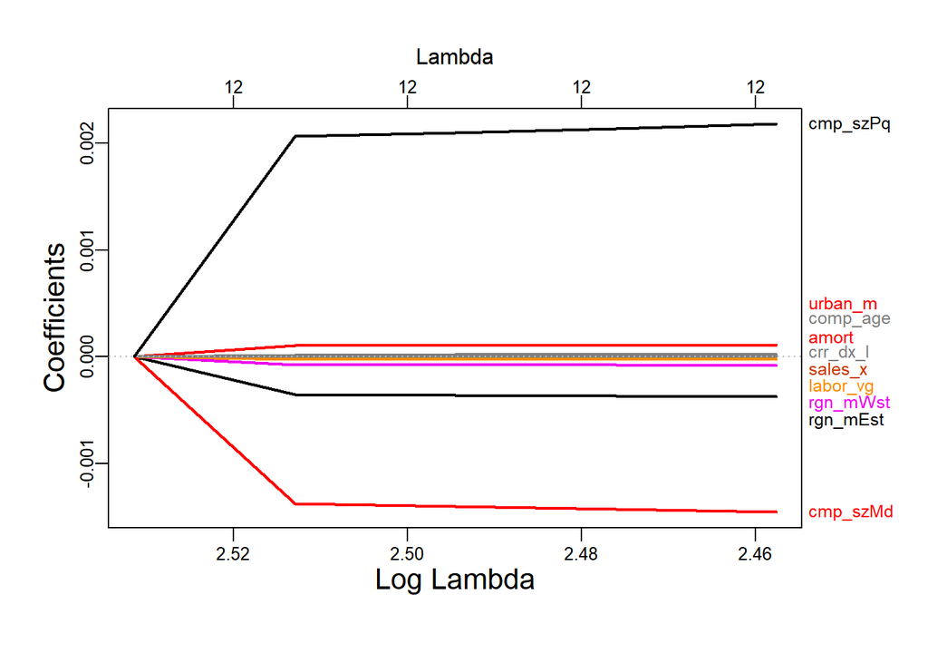

```r
ridge_sem_outliers <- glmnet(X_treino_sem_outliers, y_treino_sem_outliers,  alpha = 0,
                             nlambda = 500, family = "binomial")
plot_glmnet(ridge_sem_outliers, lwd = 2, cex.lab = 1.3)
```

A seguir, vamos fazer a validação cruzada do modelo:

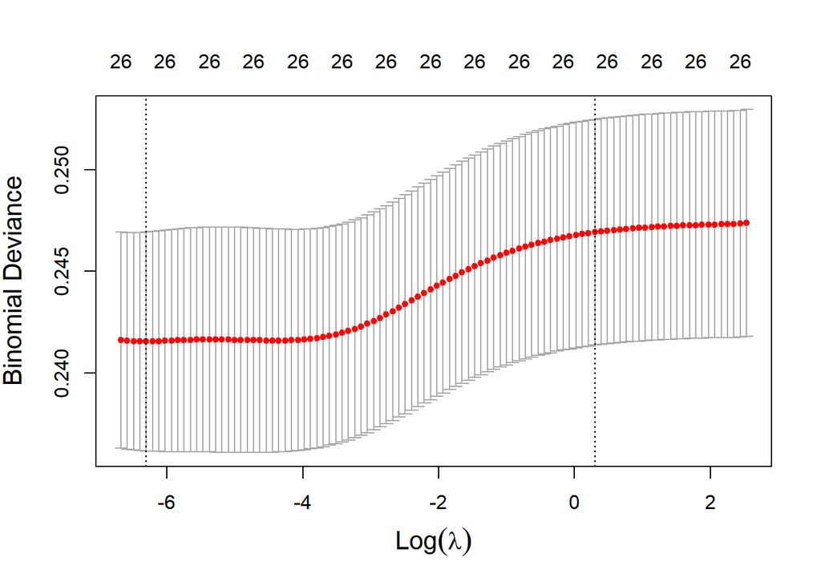

```r
cv_ridge_sem_outliers <- cv.glmnet(X_treino_sem_outliers, y_treino_sem_outliers, alpha = 0, family = "binomial")
plot(cv_ridge_sem_outliers, cex.lab = 1.3)
```

Vamos aplicar o modelo de previsão com base no melhor lambda (menor erro), estimando as probabilidades a partir da base de teste:

```r
prob_ridge_sem_outliers <- predict(ridge_sem_outliers, newx = X_teste,
                      s = cv_ridge_sem_outliers$lambda.min, type = "response")
```

E armazenar em um tibble os resultados das probabilidades obtidas pelo modelo Ridge e a respectiva classe observada:

```r
desempenho <- desempenho %>%
  bind_rows(tibble(prob = as.numeric(prob_ridge_sem_outliers),
                   classes = y_teste,
                   metodo = "ridge sem outliers"))
```

Abaixo, plotamos o gráfico com a importância de cada variável para esse modelo Rigde:

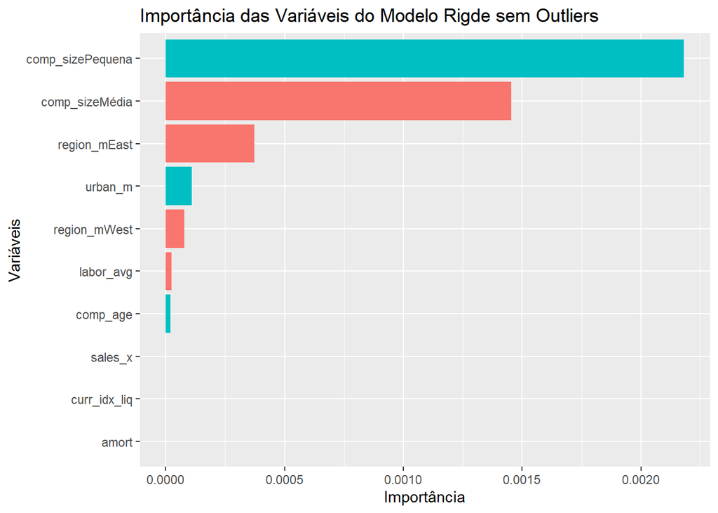

```r
vip(ridge_sem_outliers, mapping = aes(fill = Sign)) +
  labs(title = "Importância das Variáveis do Modelo Rigde sem Outliers", x = "Variáveis", y = "Importância")
```

### Regressão LASSO sem Outliers

O modelo seguinte a ser criado sem outliers é o LASSO. Assim como no modelo Ridge, foi criado o modelo LASSO e plotado o gráfico com os lambdas variando até 500:

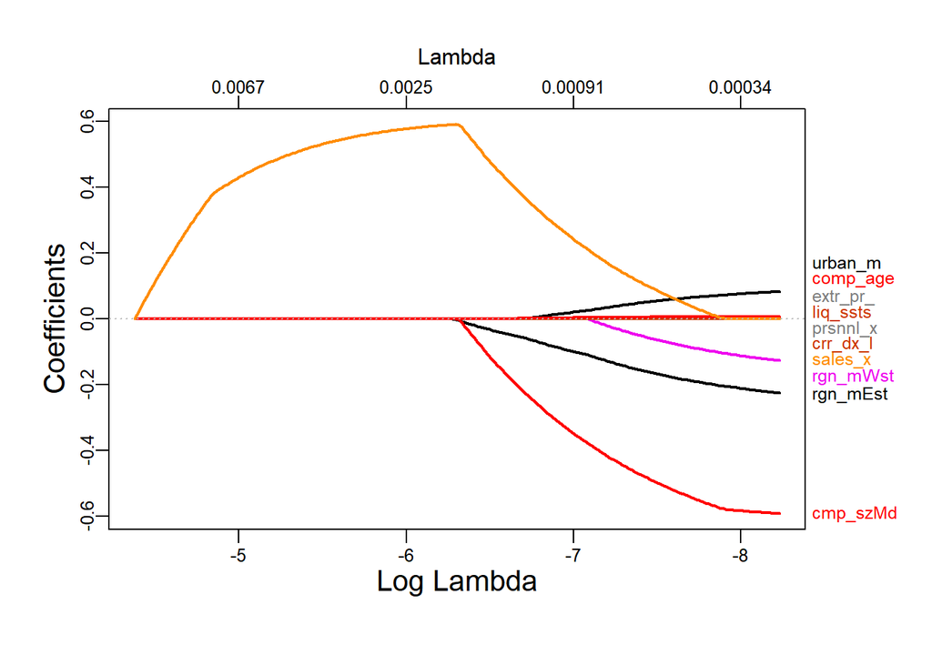

```r
lasso_sem_outliers <- glmnet(X_treino_sem_outliers, y_treino_sem_outliers,
                             alpha = 1, nlambda = 500, family = "binomial")
plot_glmnet(lasso_sem_outliers, lwd = 2, cex.lab = 1.3)
```

O próximo passo é fazer a validação cruzada do modelo:

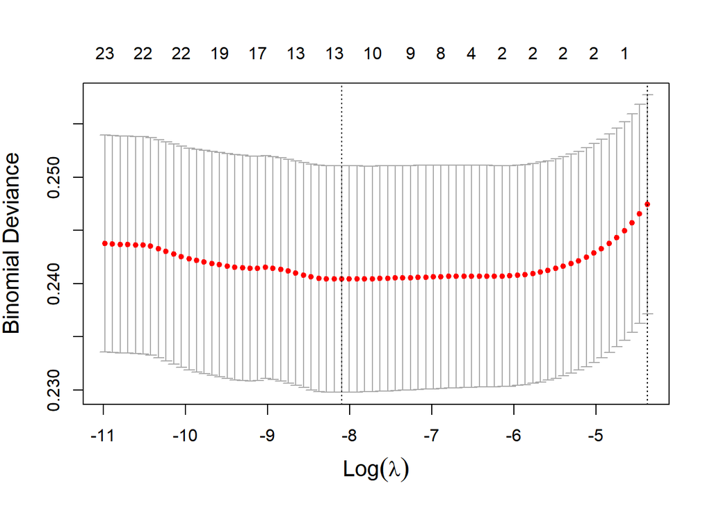

```r
cv_lasso_sem_outliers <- cv.glmnet(X_treino_sem_outliers, y_treino_sem_outliers, alpha = 1, family = "binomial")
plot(cv_lasso_sem_outliers, cex.lab = 1.3)
```

Agora, será aplicado o modelo de previsão com base no melhor lambda (menor erro), estimando as probabilidades a partir da base de teste:

```r
prob_lasso_sem_outliers <- predict(lasso_sem_outliers, newx = X_teste,
                                   s = cv_lasso_sem_outliers$lambda.min, type = "response")
```

E armazenado em um tibble os resultados das probabilidades obtidas pelo modelo Lasso e a respectiva classe observada:

```r
desempenho <- desempenho %>%
  bind_rows(tibble(prob = as.numeric(prob_lasso_sem_outliers),
                   classes = y_teste,
                   metodo = "lasso sem outliers"))
```

Abaixo, foi plotado o gráfico com a importância de cada variável para esse modelo:

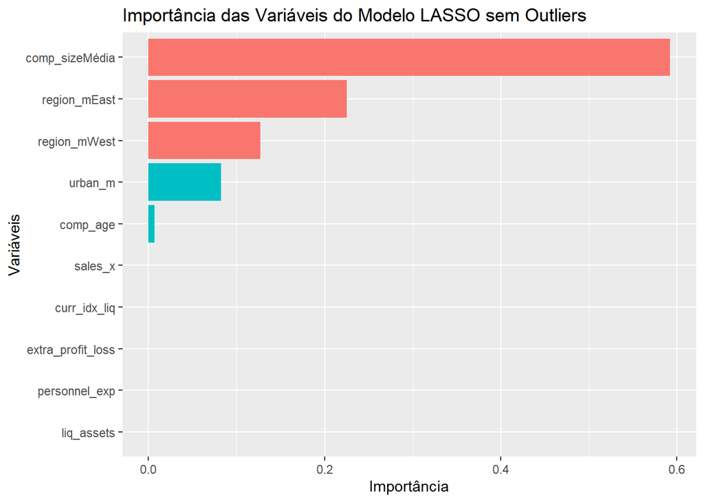

```r
vip(lasso_sem_outliers, mapping = aes(fill = Sign)) +
  labs(title = "Importância das Variáveis do Modelo LASSO sem Outliers", x = "Variáveis", y = "Importância")
```

### Floresta Aleatória sem Outliers

O próximo modelo sem outliers que será criado e testado é o de floresta aleatória com 500 árvores e com todas as variáveis:

```r
rf_sem_outliers <- ranger(will_close ~ ., probability = TRUE, data = treino_sem_outliers)
```

Para essa floresta aleatória com 500 árvores e com todas as variáveis, vamos fazer a previsão a partir dos dados de teste:

```r
prob_rf_sem_outliers <- predict(rf_sem_outliers, teste)$predictions[,2]
```

E armazenando em um tibble os resultados das probabilidades obtidas pelo modelo de floresta aleatória e a respectiva classe observada:

```r
desempenho <- desempenho %>%
  bind_rows(tibble(prob = prob_rf_sem_outliers,
                   classes = teste$will_close,
                   metodo = "floresta aleatória sem outliers"))
```

Abaixo, plotamos o gráfico com a importância de cada variável para esse modelo de floresta aleatória:

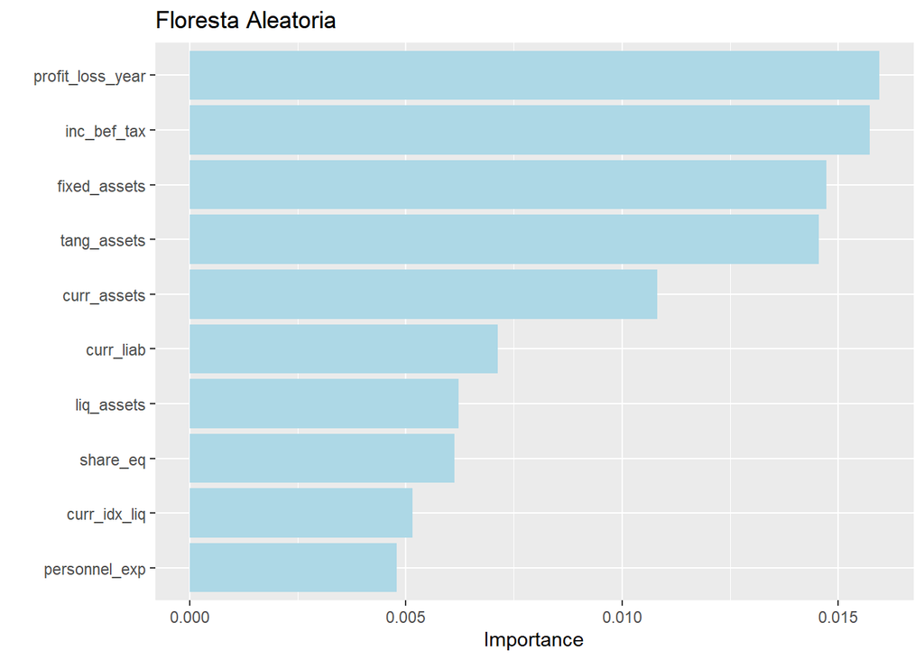

```r
vip(ranger(will_close ~ ., probability = TRUE, importance = "permutation", data = dados_sem_outliers), aesthetics = list(fill = "lightblue")) + labs(title = "Floresta Aleatoria")
```

Agora, vamos iterar para testar o número de árvores de 1 a 500, bem como o número de variáveis por split, plotar o resultado dessa iteração:

```r
result_arvores_sem_outliers <- crossing(mtry = c(2, 4, 8, 12, 16, 20, 23), #número de variáveis por split a ser testados
                       n_arvores = c(1:10, seq(10, 500, 10)))

itera_sem_outliers <- function(mtry, n_arvores) {
  rf_itera_sem_outliers <- ranger(will_close ~ ., probability = TRUE, num.trees = n_arvores, mtry = mtry, data = treino_sem_outliers)
  return(rf_itera_sem_outliers$prediction.error)
}
result_arvores_sem_outliers <- result_arvores_sem_outliers %>%
  mutate(erro = map2_dbl(mtry, n_arvores, itera_sem_outliers))
head(result_arvores_sem_outliers)
```

```
## # A tibble: 6 × 3
##    mtry n_arvores   erro
##   <dbl>     <dbl>  <dbl>
## 1     2         1 0.0451
## 2     2         2 0.0416
## 3     2         3 0.0401
## 4     2         4 0.0374
## 5     2         5 0.0361
## 6     2         6 0.0358
```

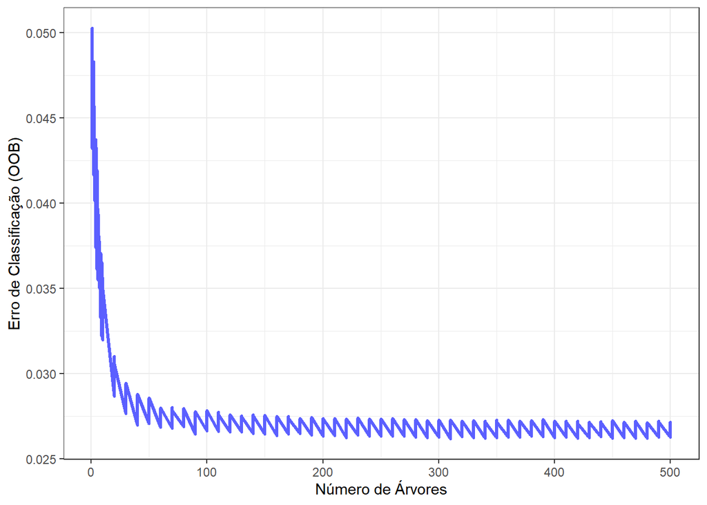

```r
result_arvores_sem_outliers %>% ggplot(aes(n_arvores, erro)) +
 geom_line(color = "#5B5FFF", size = 1.2) +
 labs(x = "Número de Árvores", y = "Erro de Classificação (OOB)") +
 theme_bw()
```

A partir da iteração acima, vamos obter os dados da floresta ótima (número de árvores e número de variáveis por split) com o menor erro:

```r
floresta_otima_sem_outliers <- result_arvores_sem_outliers %>% as_tibble() %>% filter(erro== min(erro))#Obtendo dados da floresta ótima
mtry_otimo_sem_outliers <- floresta_otima_sem_outliers$mtry #numero de arvores para floresta otima
n_arvores_otimo_sem_outliers <- floresta_otima_sem_outliers$n_arvores # variaveis por split
```

E criar o modelo de floresta aleatória ótima:

```r
rf_otima_sem_outliers <- ranger(will_close ~ ., probability = TRUE, num.trees = n_arvores_otimo_sem_outliers,
                   mtry = mtry_otimo_sem_outliers, data = treino_sem_outliers)
```

Para essa floresta aleatória ótima, vamos fazer a previsão a partir dos dados de teste:

```r
prob_rf_otima_sem_outliers <- predict(rf_otima_sem_outliers, teste)$predictions[,2]
```

```r
desempenho <- desempenho %>%
  bind_rows(tibble(prob = prob_rf_otima_sem_outliers,
                   classes = teste$will_close,
                   metodo = "floresta aleatória ótima sem outliers"))
```

Abaixo, plotamos o gráfico com a importância de cada variável para esse modelo de floresta aleatória otimizada:

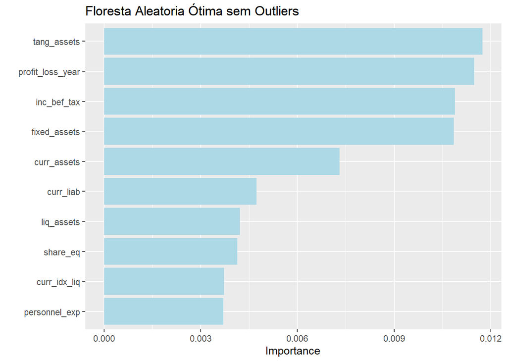

```r
vip(ranger(will_close ~ ., probability = TRUE, importance = "permutation", num.trees = n_arvores_otimo_sem_outliers, mtry = mtry_otimo_sem_outliers, data = treino_sem_outliers),
    aesthetics = list(fill = "lightblue")) + labs(title = "Floresta Aleatoria Ótima sem Outliers")
```

### Boosting sem outliers

Agora, será criado e testado nesse ciclo de modelagem é o Boosting com 500 árvores e taxa de aprendizagem 0,05 sem os outliers:

```r
(fit_bst_sem_outliers <- gbm(will_close ~ ., distribution = "bernoulli", n.trees = 500,
                interaction.depth = 4, shrinkage = 0.05, data = treino_sem_outliers))
```

```
## gbm(formula = will_close ~ ., distribution = "bernoulli", data = treino_sem_outliers,
##     n.trees = 500, interaction.depth = 4, shrinkage = 0.05)
## A gradient boosted model with bernoulli loss function.
## 500 iterations were performed.
## There were 24 predictors of which 23 had non-zero influence.
```

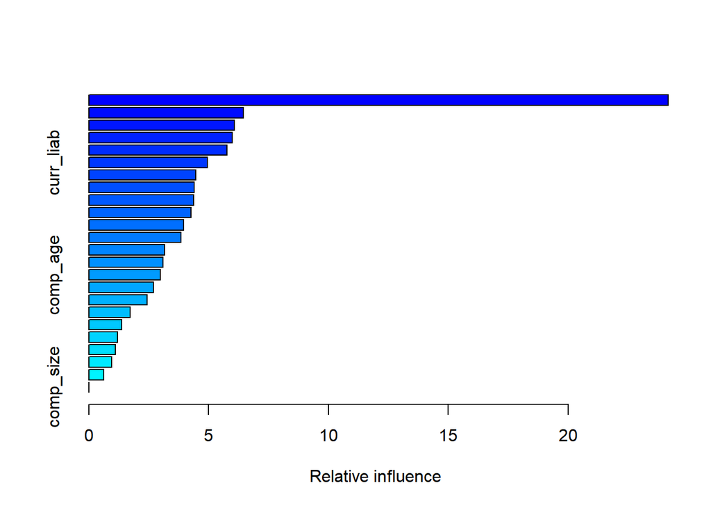

```
##                                 var    rel.inf
## sales_x                     sales_x 24.1712205
## share_eq                   share_eq  6.4469977
## liq_assets               liq_assets  6.0791358
## curr_idx_liq           curr_idx_liq  5.9759820
## curr_assets             curr_assets  5.7551928
## curr_liab                 curr_liab  4.9379389
## material_exp           material_exp  4.4612825
## inventories             inventories  4.3971098
## inc_bef_tax             inc_bef_tax  4.3708422
## personnel_exp         personnel_exp  4.2703725
## labor_avg                 labor_avg  3.9546279
## amort                         amort  3.8481777
## subscribed_cap       subscribed_cap  3.1549451
## fixed_assets           fixed_assets  3.0943527
## comp_age                   comp_age  2.9838591
## profit_loss_year   profit_loss_year  2.6940158
## intang_assets         intang_assets  2.4380770
## tang_assets             tang_assets  1.7264427
## extra_exp                 extra_exp  1.3627050
## extra_profit_loss extra_profit_loss  1.1914362
## urban_m                     urban_m  1.1128752
## region_m                   region_m  0.9495473
## extra_inc                 extra_inc  0.6228635
## comp_size                 comp_size  0.0000000
```

```r
summary(fit_bst_sem_outliers)
```

O passo seguinte é fazer a validação cruzadas do modelo para obter o número de árvores ótimo:

```r
fit_cv_sem_outliers <- gbm(will_close ~ ., data = treino_sem_outliers, cv.folds = 5, n.trees = 500,
              interaction.depth = 4, distribution = "bernoulli", shrinkage = 0.05)

num_arv_boost_sem_outliers <- gbm.perf(fit_cv_sem_outliers, method = "cv") #obtendo a árvore ótima
```

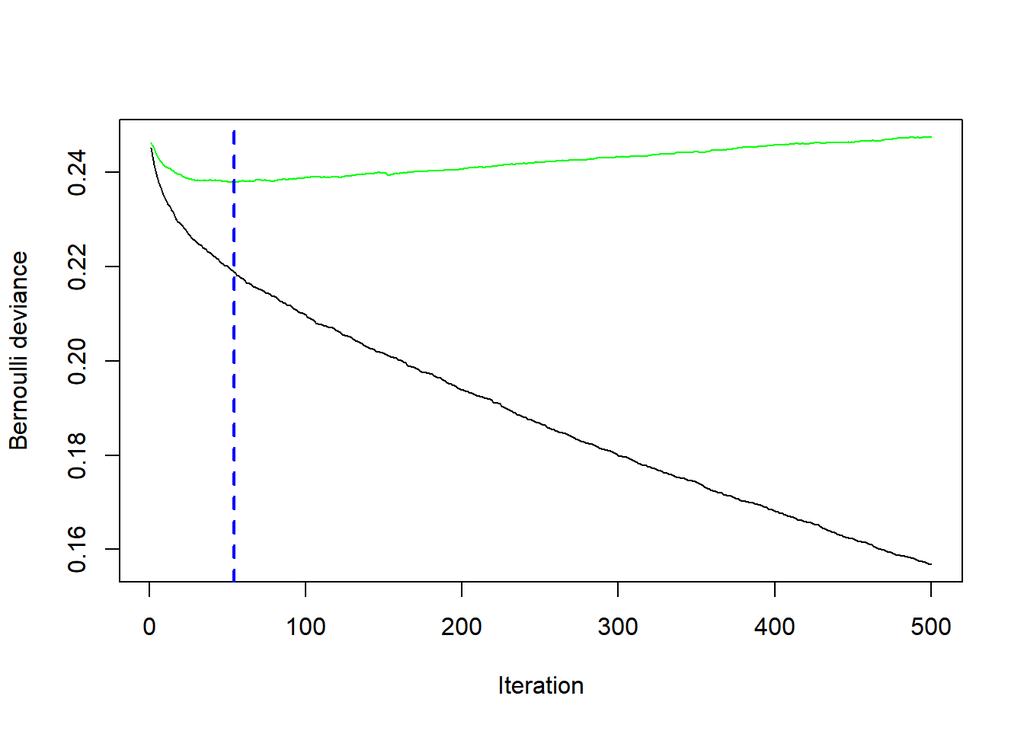

Aplicando o modelo de previsão com base na melhor quantidade de árvores (menor erro) e estimando as probabilidades a partir da base de teste, temos:

```r
prob_gbm_sem_outliers <- predict(fit_cv_sem_outliers, teste, n.trees = num_arv_boost_sem_outliers, type = "response")
```

```r
desempenho <- desempenho %>%
  bind_rows(tibble(prob = prob_gbm_sem_outliers,
                   classes = teste$will_close,
                   metodo = "boosting sem outliers"))
```

### Análise dos Modelos Estimados

Vamos plotar a curva ROC:

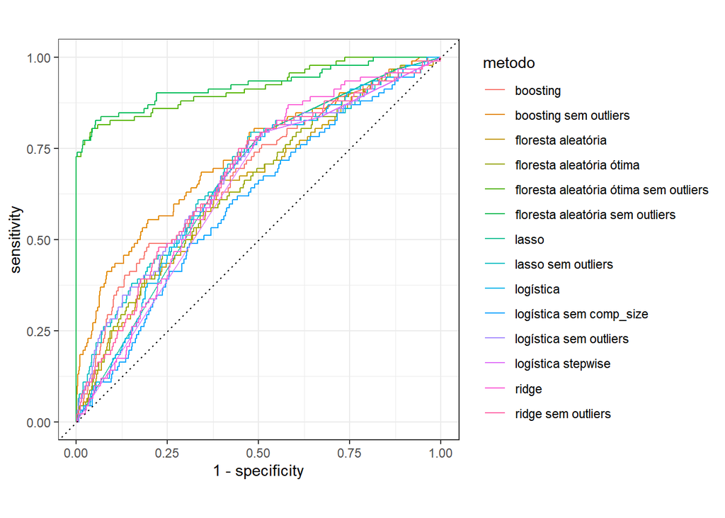

```r
desempenho %>%
  mutate(classes = factor(classes)) %>%
  group_by(metodo) %>%
  roc_curve(classes, prob, event_level = "second") %>%
  autoplot()
```

Vamos analisar AUC para cada modelo estimado:

```r
desempenho %>%
  mutate(classes = factor(classes)) %>%
  group_by(metodo) %>%
  roc_auc(classes, prob, event_level = "second") %>%
  arrange(desc(.estimate))
```

```
## # A tibble: 14 × 4
##    metodo                                .metric .estimator .estimate
##    <chr>                                 <chr>   <chr>          <dbl>
##  1 floresta aleatória sem outliers       roc_auc binary         0.924
##  2 floresta aleatória ótima sem outliers roc_auc binary         0.917
##  3 boosting sem outliers                 roc_auc binary         0.726
##  4 boosting                              roc_auc binary         0.679
##  5 lasso sem outliers                    roc_auc binary         0.677
##  6 logística sem outliers                roc_auc binary         0.674
##  7 ridge sem outliers                    roc_auc binary         0.671
##  8 ridge                                 roc_auc binary         0.660
##  9 lasso                                 roc_auc binary         0.658
## 10 logística                             roc_auc binary         0.656
## 11 floresta aleatória ótima              roc_auc binary         0.646
## 12 floresta aleatória                    roc_auc binary         0.640
## 13 logística stepwise                    roc_auc binary         0.636
## 14 logística sem comp_size               roc_auc binary         0.600
```